# Q1 Feature engineering

Here, you are going to create features from a very simple dataset: retail transaction data from Kaggle. The dataset provides the customer ID, date of the transaction and transaction amount as shown in the table below. Although this may look like a very simple dataset, you will build a wide range of features. The features will then be used as inputs in several models in upcoming assignments, in which you will try to predict the client’s response to a promotion campaign.

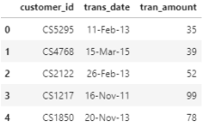

## 1.1 Import the data and create the anchor date columns

In order to create features, you need to create some anchor dates. The most typical for transaction data is the end of the month and the year.

```python
import pandas as pd
import numpy as np
import seaborn as sns
import matplotlib
import matplotlib.pyplot as plt
import matplotlib.dates as mdates
import imputena as imp
import missingno as mno
from adjustText import adjust_text
from mpl_toolkits.mplot3d import Axes3D
from matplotlib.ticker import ScalarFormatter
from matplotlib.ticker import MaxNLocator
from sklearn import preprocessing as prep
from sklearn.decomposition import PCA
from sklearn.preprocessing import StandardScaler
from sklearn.preprocessing import MaxAbsScaler
from sklearn.model_selection import train_test_split
from sklearn import linear_model
from sklearn.linear_model import LinearRegression
from sklearn.cross_decomposition import PLSRegression
from itertools import product

# from bokeh.models import ColumnDataSource, LabelSet, Arrow, NormalHead, OpenHead, VeeHead, ColorBar
# from bokeh.plotting import figure, output_file, show
# from bokeh.transform import linear_cmap
# from bokeh.palettes import RdBu
```

### 1. Import the dataset as txn1 and identify the number of rows.

```python
txn1 = pd.read_csv('Retail_Data_Transactions.csv')
txn1
```

|  | customer_id | trans_date | tran_amount |
| --- | --- | --- | --- |
| 0 | CS5295 | 11-Feb-13 | 35 |
| 1 | CS4768 | 15-Mar-15 | 39 |
| 2 | CS2122 | 26-Feb-13 | 52 |
| 3 | CS1217 | 16-Nov-11 | 99 |
| 4 | CS1850 | 20-Nov-13 | 78 |
| ... | ... | ... | ... |
| 124995 | CS8433 | 26-Jun-11 | 64 |
| 124996 | CS7232 | 19-Aug-14 | 38 |
| 124997 | CS8731 | 28-Nov-14 | 42 |
| 124998 | CS8133 | 14-Dec-13 | 13 |
| 124999 | CS7996 | 13-Dec-14 | 36 |

125000 rows × 3 columns

```python
txn1.shape
```

```
(125000, 3)
```

#### Identify the number of rows

The number of ROWS: 125000

### 2. The date-format in column ’trans date’ is not standard. Create a new column ’txn date’ from ’trans date’ with pd.to datetime and drop the column ’trans date’.

```python
# Adding new blank column with the name in cotations

txn1['txn_date'] = ""
txn1.head()
```

|  | customer_id | trans_date | tran_amount | txn_date |
| --- | --- | --- | --- | --- |
| 0 | CS5295 | 11-Feb-13 | 35 |  |
| 1 | CS4768 | 15-Mar-15 | 39 |  |
| 2 | CS2122 | 26-Feb-13 | 52 |  |
| 3 | CS1217 | 16-Nov-11 | 99 |  |
| 4 | CS1850 | 20-Nov-13 | 78 |  |

```python
# Conversion to DateTime format

txn1['txn_date'] = pd.to_datetime(txn1['trans_date'])
```

```python
# Deleting a column

txn1.drop(columns = ['trans_date'], inplace = True)
txn1.head()
```

|  | customer_id | tran_amount | txn_date |
| --- | --- | --- | --- |
| 0 | CS5295 | 35 | 2013-02-11 |
| 1 | CS4768 | 39 | 2015-03-15 |
| 2 | CS2122 | 52 | 2013-02-26 |
| 3 | CS1217 | 99 | 2011-11-16 |
| 4 | CS1850 | 78 | 2013-11-20 |

```python
type(txn1['txn_date'])
```

```
pandas.core.series.Series
```

### 3. Identify the min() and max() of column ’txn date’.

#### Minimum Transaction date

```python
txn1['txn_date'].min()
```

```
Timestamp('2011-05-16 00:00:00')
```

#### Maximum Transaction date

```python
txn1['txn_date'].max()
```

```
Timestamp('2015-03-16 00:00:00')
```

### 4. Create the column ’ME DT’: the last day of the month in the ’trans date’ column. DateOffset objects is a simple way to do this in pandas.

ASSUMPTION: 'trans date' = 'txn_date', essentially because the latter is derived from the former. The only difference is the format, no numerical changes have taken place.

```python
txn1['ME DT'] = ""
```

```python
txn1['ME DT'] = txn1['txn_date'] + pd.offsets.MonthEnd(n=0)
txn1
```

|  | customer_id | tran_amount | txn_date | ME DT |
| --- | --- | --- | --- | --- |
| 0 | CS5295 | 35 | 2013-02-11 | 2013-02-28 |
| 1 | CS4768 | 39 | 2015-03-15 | 2015-03-31 |
| 2 | CS2122 | 52 | 2013-02-26 | 2013-02-28 |
| 3 | CS1217 | 99 | 2011-11-16 | 2011-11-30 |
| 4 | CS1850 | 78 | 2013-11-20 | 2013-11-30 |
| ... | ... | ... | ... | ... |
| 124995 | CS8433 | 64 | 2011-06-26 | 2011-06-30 |
| 124996 | CS7232 | 38 | 2014-08-19 | 2014-08-31 |
| 124997 | CS8731 | 42 | 2014-11-28 | 2014-11-30 |
| 124998 | CS8133 | 13 | 2013-12-14 | 2013-12-31 |
| 124999 | CS7996 | 36 | 2014-12-13 | 2014-12-31 |

125000 rows × 4 columns

### 5. Create the column ’YEAR’: the year in the ’trans date’ column. DatetimeIndex with attribute .year will help you do so.

```python
txn1['YEAR'] = ""
```

```python
txn1['YEAR'] = txn1['txn_date'].dt.year
txn1
```

|  | customer_id | tran_amount | txn_date | ME DT | YEAR |
| --- | --- | --- | --- | --- | --- |
| 0 | CS5295 | 35 | 2013-02-11 | 2013-02-28 | 2013 |
| 1 | CS4768 | 39 | 2015-03-15 | 2015-03-31 | 2015 |
| 2 | CS2122 | 52 | 2013-02-26 | 2013-02-28 | 2013 |
| 3 | CS1217 | 99 | 2011-11-16 | 2011-11-30 | 2011 |
| 4 | CS1850 | 78 | 2013-11-20 | 2013-11-30 | 2013 |
| ... | ... | ... | ... | ... | ... |
| 124995 | CS8433 | 64 | 2011-06-26 | 2011-06-30 | 2011 |
| 124996 | CS7232 | 38 | 2014-08-19 | 2014-08-31 | 2014 |
| 124997 | CS8731 | 42 | 2014-11-28 | 2014-11-30 | 2014 |
| 124998 | CS8133 | 13 | 2013-12-14 | 2013-12-31 | 2013 |
| 124999 | CS7996 | 36 | 2014-12-13 | 2014-12-31 | 2014 |

125000 rows × 5 columns

```python
# Confirmation with the snapshot provided in the question

txn1.iloc[55:60,:]
```

|  | customer_id | tran_amount | txn_date | ME DT | YEAR |
| --- | --- | --- | --- | --- | --- |
| 55 | CS2662 | 88 | 2014-08-31 | 2014-08-31 | 2014 |
| 56 | CS2209 | 35 | 2012-03-12 | 2012-03-31 | 2012 |
| 57 | CS4530 | 40 | 2011-06-05 | 2011-06-30 | 2011 |
| 58 | CS2848 | 53 | 2013-02-04 | 2013-02-28 | 2013 |
| 59 | CS2596 | 55 | 2011-09-19 | 2011-09-30 | 2011 |

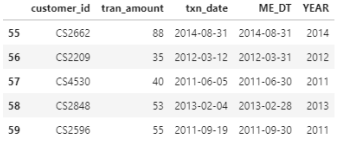

## 1.2 Create features that capture annual spending

Here the approach is to capture the client’s annual spending. The rationale behind this approach is that the clients spend is not very frequent to capture in a monthly aggregation.

### 1. Using groupby and NamedAgg create clnt_annual_aggregations, the annual aggregations dataframe: with sum, mean, std, var, sem, max, min, count as the aggregation functions. A snapshot of the output table is shown below. Notice that the output is a typical MultiIndex pandas dataframe.

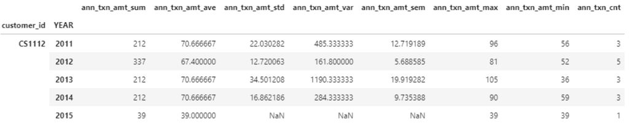

```python
# Aggregate functions to find the values, basically used to find the value for many columns at once

agg_sum = pd.NamedAgg(column = "tran_amount", aggfunc = np.sum)
agg_mean = pd.NamedAgg(column = "tran_amount", aggfunc = np.mean)
agg_std = pd.NamedAgg(column = "tran_amount", aggfunc = np.std)
agg_var = pd.NamedAgg(column = "tran_amount", aggfunc = np.var)
agg_sem = pd.NamedAgg(column = "tran_amount", aggfunc = 'sem')
agg_max = pd.NamedAgg(column = "tran_amount", aggfunc = np.max)
agg_min = pd.NamedAgg(column = "tran_amount", aggfunc = np.min)
agg_count = pd.NamedAgg(column = "tran_amount", aggfunc = 'count')

# Used as an attribute in the groupby code

clnt_annual_aggregations = txn1.groupby(['customer_id', 'YEAR']).agg(ann_txn_amt_sum = agg_sum,
                                                                     ann_txn_amt_mean = agg_mean,
                                                                     ann_txn_amt_std = agg_std,
                                                                     ann_txn_amt_var = agg_var,
                                                                     ann_txn_amt_sem = agg_sem,
                                                                     ann_txn_amt_max = agg_max,
                                                                     ann_txn_amt_min = agg_min,
                                                                     ann_txn_amt_count = agg_count)
clnt_annual_aggregations
```

| customer_id | YEAR | ann_txn_amt_sum | ann_txn_amt_mean | ann_txn_amt_std | ann_txn_amt_var | ann_txn_amt_sem | ann_txn_amt_max | ann_txn_amt_min | ann_txn_amt_count |
| --- | --- | --- | --- | --- | --- | --- | --- | --- | --- |
| CS1112 | 2011 | 212 | 70.666667 | 22.030282 | 485.333333 | 12.719189 | 96 | 56 | 3 |
|  | 2012 | 337 | 67.400000 | 12.720063 | 161.800000 | 5.688585 | 81 | 52 | 5 |
|  | 2013 | 212 | 70.666667 | 34.501208 | 1190.333333 | 19.919282 | 105 | 36 | 3 |
|  | 2014 | 212 | 70.666667 | 16.862186 | 284.333333 | 9.735388 | 90 | 59 | 3 |
|  | 2015 | 39 | 39.000000 | NaN | NaN | NaN | 39 | 39 | 1 |
| ... | ... | ... | ... | ... | ... | ... | ... | ... | ... |
| CS9000 | 2011 | 39 | 19.500000 | 4.949747 | 24.500000 | 3.500000 | 23 | 16 | 2 |
|  | 2012 | 216 | 54.000000 | 16.772994 | 281.333333 | 8.386497 | 77 | 37 | 4 |
|  | 2013 | 147 | 73.500000 | 3.535534 | 12.500000 | 2.500000 | 76 | 71 | 2 |
|  | 2014 | 97 | 24.250000 | 8.261356 | 68.250000 | 4.130678 | 35 | 16 | 4 |
|  | 2015 | 34 | 34.000000 | NaN | NaN | NaN | 34 | 34 | 1 |

31140 rows × 8 columns

### 2. Plot the histogram of the sum and count.

```
array([[<AxesSubplot:title={'center':'ann_txn_amt_sum'}>]], dtype=object)
```

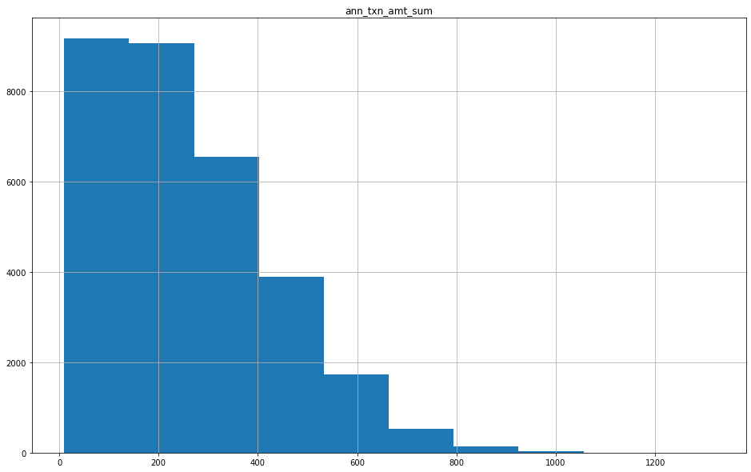

```python
# Histogram of the Annual Transactin Amount SUM

clnt_annual_aggregations.hist(column = 'ann_txn_amt_sum',
#                               by = 'YEAR',
                              figsize = (16,10))
```

```
array([[<AxesSubplot:title={'center':'ann_txn_amt_count'}>]], dtype=object)
```

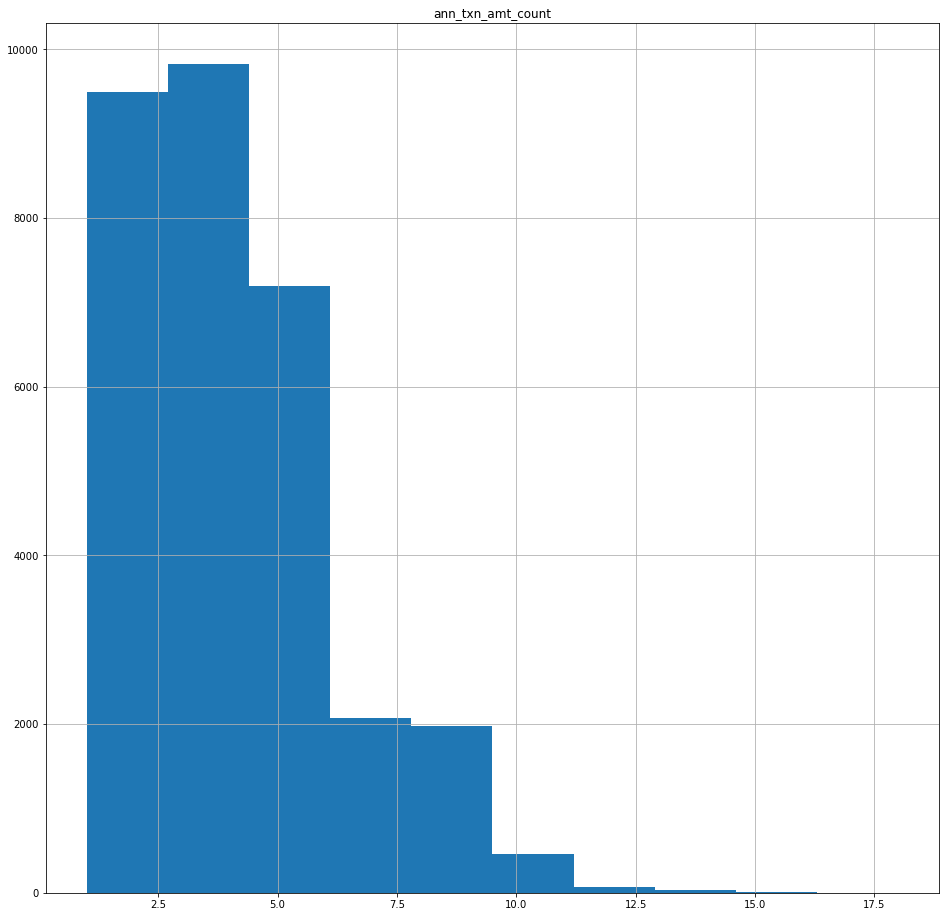

```python
# Histogram of the Annual Transactin Amount COUNT

clnt_annual_aggregations.hist(column = 'ann_txn_amt_count',
#                               by = 'YEAR',
                              figsize = (16,16))
```

```python
clnt_annual_aggregations.shape
```

```
(31140, 8)
```

### 3. Reset the index and reshape the table with the pivot table function to create the clnt_annual_aggregations pivot table shown below with 40 columns (why 40?). You should expect columns with NaN values. Impute the NaN entries when you perform the pivot table function and explain your choice of values.

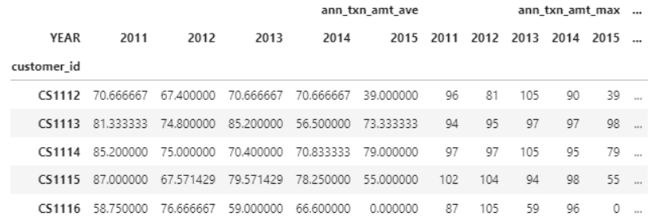

```python
clnt_annual_aggregations
```

| customer_id | YEAR | ann_txn_amt_sum | ann_txn_amt_mean | ann_txn_amt_std | ann_txn_amt_var | ann_txn_amt_sem | ann_txn_amt_max | ann_txn_amt_min | ann_txn_amt_count |
| --- | --- | --- | --- | --- | --- | --- | --- | --- | --- |
| CS1112 | 2011 | 212 | 70.666667 | 22.030282 | 485.333333 | 12.719189 | 96 | 56 | 3 |
|  | 2012 | 337 | 67.400000 | 12.720063 | 161.800000 | 5.688585 | 81 | 52 | 5 |
|  | 2013 | 212 | 70.666667 | 34.501208 | 1190.333333 | 19.919282 | 105 | 36 | 3 |
|  | 2014 | 212 | 70.666667 | 16.862186 | 284.333333 | 9.735388 | 90 | 59 | 3 |
|  | 2015 | 39 | 39.000000 | NaN | NaN | NaN | 39 | 39 | 1 |
| ... | ... | ... | ... | ... | ... | ... | ... | ... | ... |
| CS9000 | 2011 | 39 | 19.500000 | 4.949747 | 24.500000 | 3.500000 | 23 | 16 | 2 |
|  | 2012 | 216 | 54.000000 | 16.772994 | 281.333333 | 8.386497 | 77 | 37 | 4 |
|  | 2013 | 147 | 73.500000 | 3.535534 | 12.500000 | 2.500000 | 76 | 71 | 2 |
|  | 2014 | 97 | 24.250000 | 8.261356 | 68.250000 | 4.130678 | 35 | 16 | 4 |
|  | 2015 | 34 | 34.000000 | NaN | NaN | NaN | 34 | 34 | 1 |

31140 rows × 8 columns

#### Impute the NaN entries when you perform the pivot table function and explain your choice of values.

```python
# Pivot Table Function with Zero-Value Imputation

clnt_annual_aggregations_pt = pd.pivot_table(clnt_annual_aggregations,
                                             index = 'customer_id',
                                             columns = 'YEAR',
                                             fill_value = 0)           # 0-Value Imputation
clnt_annual_aggregations_pt
```

| YEAR customer_id | ann_txn_amt_count 2011 | ann_txn_amt_count 2012 | ann_txn_amt_count 2013 | ann_txn_amt_count 2014 | ann_txn_amt_count 2015 | ann_txn_amt_max 2011 | ann_txn_amt_max 2012 | ann_txn_amt_max 2013 | ann_txn_amt_max 2014 | ann_txn_amt_max 2015 | ... | ann_txn_amt_sum 2011 | ann_txn_amt_sum 2012 | ann_txn_amt_sum 2013 | ann_txn_amt_sum 2014 | ann_txn_amt_sum 2015 | ann_txn_amt_var 2011 | ann_txn_amt_var 2012 | ann_txn_amt_var 2013 | ann_txn_amt_var 2014 | ann_txn_amt_var 2015 |
| --- | --- | --- | --- | --- | --- | --- | --- | --- | --- | --- | --- | --- | --- | --- | --- | --- | --- | --- | --- | --- | --- |
| CS1112 | 3 | 5 | 3 | 3 | 1 | 96 | 81 | 105 | 90 | 39 | ... | 212 | 337 | 212 | 212 | 39 | 485.333333 | 161.800000 | 1190.333333 | 284.333333 | 0.000000 |
| CS1113 | 3 | 5 | 5 | 4 | 3 | 94 | 95 | 97 | 97 | 98 | ... | 244 | 374 | 426 | 226 | 220 | 444.333333 | 290.200000 | 171.200000 | 781.666667 | 745.333333 |
| CS1114 | 5 | 2 | 5 | 6 | 1 | 97 | 97 | 105 | 95 | 79 | ... | 426 | 150 | 352 | 425 | 79 | 94.700000 | 968.000000 | 619.300000 | 726.166667 | 0.000000 |
| CS1115 | 3 | 7 | 7 | 4 | 1 | 102 | 104 | 94 | 98 | 55 | ... | 261 | 473 | 557 | 313 | 55 | 225.000000 | 477.285714 | 110.952381 | 512.250000 | 0.000000 |
| CS1116 | 4 | 3 | 1 | 5 | 0 | 87 | 105 | 59 | 96 | 0 | ... | 235 | 230 | 59 | 333 | 0 | 449.583333 | 908.333333 | 0.000000 | 636.800000 | 0.000000 |
| ... | ... | ... | ... | ... | ... | ... | ... | ... | ... | ... | ... | ... | ... | ... | ... | ... | ... | ... | ... | ... | ... |
| CS8996 | 2 | 3 | 2 | 6 | 0 | 38 | 38 | 50 | 79 | 0 | ... | 62 | 101 | 83 | 336 | 0 | 98.000000 | 20.333333 | 144.500000 | 481.600000 | 0.000000 |
| CS8997 | 2 | 4 | 6 | 2 | 0 | 47 | 49 | 75 | 45 | 0 | ... | 90 | 158 | 211 | 84 | 0 | 8.000000 | 45.666667 | 441.366667 | 18.000000 | 0.000000 |
| CS8998 | 2 | 5 | 2 | 4 | 0 | 69 | 79 | 75 | 49 | 0 | ... | 128 | 272 | 94 | 130 | 0 | 50.000000 | 505.300000 | 1568.000000 | 219.666667 | 0.000000 |
| CS8999 | 3 | 4 | 3 | 2 | 0 | 64 | 30 | 39 | 24 | 0 | ... | 156 | 101 | 84 | 42 | 0 | 333.000000 | 21.583333 | 103.000000 | 18.000000 | 0.000000 |
| CS9000 | 2 | 4 | 2 | 4 | 1 | 23 | 77 | 76 | 35 | 34 | ... | 39 | 216 | 147 | 97 | 34 | 24.500000 | 281.333333 | 12.500000 | 68.250000 | 0.000000 |

6889 rows × 40 columns

#### Why 40?

There's 5 years and 8 variables to calculate for each year, thus 40 columns in total.

#### Explain your choice of Imputation

I have choosen to do a 0 value imputation here, because these are transaction counts, sums and maxs', etc essentially, therfore they do if a trasaction is not made thus the above aggregations are not possible and thus;

```
    done = Positive integer
    OR
    not done = 0
```

### 4. The pivoted object you created is a MultiIndex object with hierarchical indexes. You can see the first level (i.e. 0) in the snapshot above with names ’ann txn amt ave’, ’ann txn amt max’ (and more as indicated by the ...) and the second level (i.e. 1) with names ’2011’, ’2012’, etc. You can confirm the multiple levels of the columns with the following two expressions

clnt_annual_aggregations_pivot . columns . nlevels

clnt_annual_aggregations_pivot . columns

```python
# df.columns.nlevels or df.index.nlevels used to check the number of levels in columns and index respectively.

clnt_annual_aggregations_pt.columns.nlevels
```

```
2
```

```python
# Similar to the above but returns values of in each column or index respectively

clnt_annual_aggregations_pt.columns
```

```
MultiIndex([('ann_txn_amt_count', 2011),
            ('ann_txn_amt_count', 2012),
            ('ann_txn_amt_count', 2013),
            ('ann_txn_amt_count', 2014),
            ('ann_txn_amt_count', 2015),
            (  'ann_txn_amt_max', 2011),
            (  'ann_txn_amt_max', 2012),
            (  'ann_txn_amt_max', 2013),
            (  'ann_txn_amt_max', 2014),
            (  'ann_txn_amt_max', 2015),
            ( 'ann_txn_amt_mean', 2011),
            ( 'ann_txn_amt_mean', 2012),
            ( 'ann_txn_amt_mean', 2013),
            ( 'ann_txn_amt_mean', 2014),
            ( 'ann_txn_amt_mean', 2015),
            (  'ann_txn_amt_min', 2011),
            (  'ann_txn_amt_min', 2012),
            (  'ann_txn_amt_min', 2013),
            (  'ann_txn_amt_min', 2014),
            (  'ann_txn_amt_min', 2015),
            (  'ann_txn_amt_sem', 2011),
            (  'ann_txn_amt_sem', 2012),
            (  'ann_txn_amt_sem', 2013),
            (  'ann_txn_amt_sem', 2014),
            (  'ann_txn_amt_sem', 2015),
            (  'ann_txn_amt_std', 2011),
            (  'ann_txn_amt_std', 2012),
            (  'ann_txn_amt_std', 2013),
            (  'ann_txn_amt_std', 2014),
            (  'ann_txn_amt_std', 2015),
            (  'ann_txn_amt_sum', 2011),
            (  'ann_txn_amt_sum', 2012),
            (  'ann_txn_amt_sum', 2013),
            (  'ann_txn_amt_sum', 2014),
            (  'ann_txn_amt_sum', 2015),
            (  'ann_txn_amt_var', 2011),
            (  'ann_txn_amt_var', 2012),
            (  'ann_txn_amt_var', 2013),
            (  'ann_txn_amt_var', 2014),
            (  'ann_txn_amt_var', 2015)],
           names=[None, 'YEAR'])
```

#### What are your observations regarding the number of levels and the column names?

Based on the first line of code "clnt_annual_aggregations_pt.columns.nlevels", the number of levels in the MultiLevel Columns = 2.

As for the column names, it is observed that each particular value (sum,var,count,min,max,sem,std,mean) for annual trasaction amount (annn_txn*amt*...) is calculated for each year (2011,2012,2013,2014,2015) and place under the respective column in the 0 level.

### 5. Finally, you want to save the dataframe clnt annual aggregations pivot as an .xlsx file for future use in the machine learning assignment. To do so, you want to remove the two levels in columns and create a single level with column names: ’ann txn amt ave 2011’, ’ann txn amt ave 2012’, etc. To do so, use the code snippet below prior to saving the dataframe as an Excel file.

level_0 = clnt_annual_aggregations_pivot . columns . get_level_values ( 0 ) . astype ( str)

level_1 = clnt_annual_aggregations_pivot . columns . get_level_values ( 1 ) . astype ( str)

clnt_annual_aggregations_pivot . columns = level*0 + ’*’ + level_1

```python
# Conversion from MultiLevel to Single Level
# Extracting the labels of each column and storing the value in the left variable.

level_0 = clnt_annual_aggregations_pt.columns.get_level_values(0).astype(str)
level_1 = clnt_annual_aggregations_pt.columns.get_level_values(1).astype(str)
```

```python
# Reassigning the columns with a new representation of the MultiLevel into a Single Level

clnt_annual_aggregations_pt.columns = level_0 + '_' + level_1
```

```python
clnt_annual_aggregations_pt
```

| customer_id | ann_txn_amt_count_2011 | ann_txn_amt_count_2012 | ann_txn_amt_count_2013 | ann_txn_amt_count_2014 | ann_txn_amt_count_2015 | ann_txn_amt_max_2011 | ann_txn_amt_max_2012 | ann_txn_amt_max_2013 | ann_txn_amt_max_2014 | ann_txn_amt_max_2015 | ... | ann_txn_amt_sum_2011 | ann_txn_amt_sum_2012 | ann_txn_amt_sum_2013 | ann_txn_amt_sum_2014 | ann_txn_amt_sum_2015 | ann_txn_amt_var_2011 | ann_txn_amt_var_2012 | ann_txn_amt_var_2013 | ann_txn_amt_var_2014 | ann_txn_amt_var_2015 |
| --- | --- | --- | --- | --- | --- | --- | --- | --- | --- | --- | --- | --- | --- | --- | --- | --- | --- | --- | --- | --- | --- |
| CS1112 | 3 | 5 | 3 | 3 | 1 | 96 | 81 | 105 | 90 | 39 | ... | 212 | 337 | 212 | 212 | 39 | 485.333333 | 161.800000 | 1190.333333 | 284.333333 | 0.000000 |
| CS1113 | 3 | 5 | 5 | 4 | 3 | 94 | 95 | 97 | 97 | 98 | ... | 244 | 374 | 426 | 226 | 220 | 444.333333 | 290.200000 | 171.200000 | 781.666667 | 745.333333 |
| CS1114 | 5 | 2 | 5 | 6 | 1 | 97 | 97 | 105 | 95 | 79 | ... | 426 | 150 | 352 | 425 | 79 | 94.700000 | 968.000000 | 619.300000 | 726.166667 | 0.000000 |
| CS1115 | 3 | 7 | 7 | 4 | 1 | 102 | 104 | 94 | 98 | 55 | ... | 261 | 473 | 557 | 313 | 55 | 225.000000 | 477.285714 | 110.952381 | 512.250000 | 0.000000 |
| CS1116 | 4 | 3 | 1 | 5 | 0 | 87 | 105 | 59 | 96 | 0 | ... | 235 | 230 | 59 | 333 | 0 | 449.583333 | 908.333333 | 0.000000 | 636.800000 | 0.000000 |
| ... | ... | ... | ... | ... | ... | ... | ... | ... | ... | ... | ... | ... | ... | ... | ... | ... | ... | ... | ... | ... | ... |
| CS8996 | 2 | 3 | 2 | 6 | 0 | 38 | 38 | 50 | 79 | 0 | ... | 62 | 101 | 83 | 336 | 0 | 98.000000 | 20.333333 | 144.500000 | 481.600000 | 0.000000 |
| CS8997 | 2 | 4 | 6 | 2 | 0 | 47 | 49 | 75 | 45 | 0 | ... | 90 | 158 | 211 | 84 | 0 | 8.000000 | 45.666667 | 441.366667 | 18.000000 | 0.000000 |
| CS8998 | 2 | 5 | 2 | 4 | 0 | 69 | 79 | 75 | 49 | 0 | ... | 128 | 272 | 94 | 130 | 0 | 50.000000 | 505.300000 | 1568.000000 | 219.666667 | 0.000000 |
| CS8999 | 3 | 4 | 3 | 2 | 0 | 64 | 30 | 39 | 24 | 0 | ... | 156 | 101 | 84 | 42 | 0 | 333.000000 | 21.583333 | 103.000000 | 18.000000 | 0.000000 |
| CS9000 | 2 | 4 | 2 | 4 | 1 | 23 | 77 | 76 | 35 | 34 | ... | 39 | 216 | 147 | 97 | 34 | 24.500000 | 281.333333 | 12.500000 | 68.250000 | 0.000000 |

6889 rows × 40 columns

```python
clnt_annual_aggregations_pt.to_excel('annual_features.xlsx')
```

#### Describe what each line of code in the box does and save the output dataframe as an Excel file annual features.xlsx. A snapshot of the desired final output is shown below.

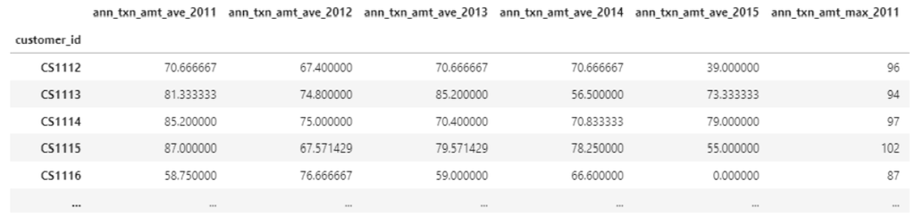

clnt_annual_aggregations_pivot . columns = level*0 + '* ' + level_1 This code is a version of formatted string that directly combines the 2 newly created variables (level_0 and level_1) with an underscore in the middle, and assigns each column it's new name that is a combination of the 'ann_txn*amt*...' & 'Year', all in a single level.

### 6. What are the possible disadvantages in capturing client transaction behavior with the annual features described in this section (if any)?

Disadvantages of capturing client transaction behavior with Annual Features

If we want to find out the behavior of a client on a monthly basis in a particular year, perhaps 2015, then it would be really difficult to gauge that value from the annual features as we derived.

## 1.3 Create monthly aggregations

Here, you want to explore the monthly sum of amounts and count of clients transactions.

### 1. Create the dataframe that captures the monthly sum and count of transactions per client (name it clnt_monthly_aggregations). Use the groupby function with the Named Aggregation feature which was introduced in pandas version 0.25.0. Make sure that you name the columns as shown in the figure sample on the right.

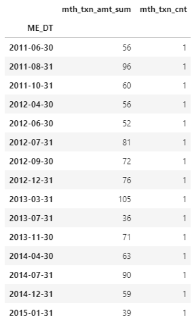

```python
# txn1
```

```python
agg_sum = pd.NamedAgg(column = "tran_amount", aggfunc = np.sum)
# agg_mean = pd.NamedAgg(column = "tran_amount", aggfunc = np.mean)
# agg_std = pd.NamedAgg(column = "tran_amount", aggfunc = np.std)
# agg_var = pd.NamedAgg(column = "tran_amount", aggfunc = np.var)
# agg_sem = pd.NamedAgg(column = "tran_amount", aggfunc = 'sem')
# agg_max = pd.NamedAgg(column = "tran_amount", aggfunc = np.max)
# agg_min = pd.NamedAgg(column = "tran_amount", aggfunc = np.min)
agg_count = pd.NamedAgg(column = "tran_amount", aggfunc = 'count')

clnt_monthly_aggregations = txn1.groupby(['customer_id', 'ME DT']).agg(mth_txn_amt_sum = agg_sum,
#                                                                      mth_txn_amt_mean = agg_mean,
#                                                                      mth_txn_amt_std = agg_std,
#                                                                      mth_txn_amt_var = agg_var,
#                                                                      mth_txn_amt_sem = agg_sem,
#                                                                      mth_txn_amt_max = agg_max,
#                                                                      mth_txn_amt_min = agg_min,
                                                                       mth_txn_amt_count = agg_count)
clnt_monthly_aggregations
```

| customer_id | ME DT | mth_txn_amt_sum | mth_txn_amt_count |
| --- | --- | --- | --- |
| CS1112 | 2011-06-30 | 56 | 1 |
|  | 2011-08-31 | 96 | 1 |
|  | 2011-10-31 | 60 | 1 |
|  | 2012-04-30 | 56 | 1 |
|  | 2012-06-30 | 52 | 1 |
| ... | ... | ... | ... |
| CS9000 | 2014-01-31 | 16 | 1 |
|  | 2014-05-31 | 20 | 1 |
|  | 2014-07-31 | 26 | 1 |
|  | 2014-08-31 | 35 | 1 |
|  | 2015-02-28 | 34 | 1 |

103234 rows × 2 columns

```python
clnt_monthly_aggregations.shape
```

```
(103234, 2)
```

```python
clnt_monthly_aggregations.iloc[0:15,:]
```

| customer_id | ME DT | mth_txn_amt_sum | mth_txn_amt_count |
| --- | --- | --- | --- |
| CS1112 | 2011-06-30 | 56 | 1 |
|  | 2011-08-31 | 96 | 1 |
|  | 2011-10-31 | 60 | 1 |
|  | 2012-04-30 | 56 | 1 |
|  | 2012-06-30 | 52 | 1 |
|  | 2012-07-31 | 81 | 1 |
|  | 2012-09-30 | 72 | 1 |
|  | 2012-12-31 | 76 | 1 |
|  | 2013-03-31 | 105 | 1 |
|  | 2013-07-31 | 36 | 1 |
|  | 2013-11-30 | 71 | 1 |
|  | 2014-04-30 | 63 | 1 |
|  | 2014-07-31 | 90 | 1 |
|  | 2014-12-31 | 59 | 1 |
|  | 2015-01-31 | 39 | 1 |

### 2. Create a histogram of both columns you created. What are your observations? What are the most common and maximum values for each column? How do they compare with the ones in section 1.2?

The output dataframe should look like the snapshot shown on the right for client with ID CS1112 (confirm this with slicing your output dataframe).

Most clients in this dataset shop a few times a year. For example, the client with ’customer id’ CS1112 shown here made purchases in 15 out of 47 months of data in the txn table. The information in this dataset is ”irregular”; some clients may have an entry for a month, while others do not have an entry (e.g. when they don’t shop for this particular month).

```
array([[<AxesSubplot:title={'center':'mth_txn_amt_sum'}>,
        <AxesSubplot:title={'center':'mth_txn_amt_count'}>]], dtype=object)
```

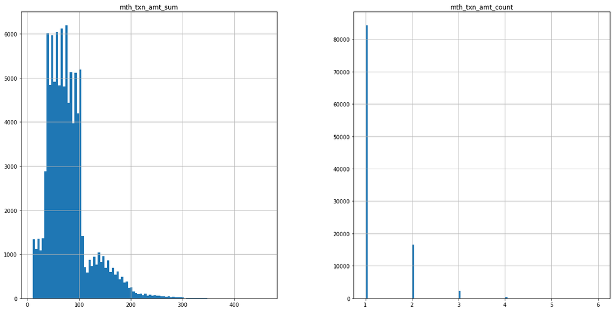

```python
clnt_monthly_aggregations.hist(column = ['mth_txn_amt_sum', 'mth_txn_amt_count'],
#                                by = 'ME DT',
                               figsize = (20,10), bins = 100)
```

#### What are your observations?

The histograms are skwed to the left side of the table. There are more number of people with less number of trasactions and vice versa.

#### How do they compare with the ones in section 1.2?

They both are skwed to the left hand side, with transactions happening more with lower values and, those ith high amount have less frequency.

## 1.4 Create the base table for the rolling window features

In order to create the rolling window features (more on this in the next section), you need to create a base table with all possible combinations of ’customer id’ and ’ME DT’. For example, customer CS1112 should have 47 entries, one for each month, in which 15 will have the value of transaction amount and the rest 32 will have zero value for transaction amount. This will essentially help you convert the ”irregular” clnt monthly aggregations table into a ”regular” one.

### 1. Create the numpy array of the unique elements in columns ’customer id’ and ’ME DT’ of the txn table you created in section 1.1. Confirm that you have 6,889 unique clients and 47 unique month-end-dates.

```python
txn1
```

|  | customer_id | tran_amount | txn_date | ME DT | YEAR |
| --- | --- | --- | --- | --- | --- |
| 0 | CS5295 | 35 | 2013-02-11 | 2013-02-28 | 2013 |
| 1 | CS4768 | 39 | 2015-03-15 | 2015-03-31 | 2015 |
| 2 | CS2122 | 52 | 2013-02-26 | 2013-02-28 | 2013 |
| 3 | CS1217 | 99 | 2011-11-16 | 2011-11-30 | 2011 |
| 4 | CS1850 | 78 | 2013-11-20 | 2013-11-30 | 2013 |
| ... | ... | ... | ... | ... | ... |
| 124995 | CS8433 | 64 | 2011-06-26 | 2011-06-30 | 2011 |
| 124996 | CS7232 | 38 | 2014-08-19 | 2014-08-31 | 2014 |
| 124997 | CS8731 | 42 | 2014-11-28 | 2014-11-30 | 2014 |
| 124998 | CS8133 | 13 | 2013-12-14 | 2013-12-31 | 2013 |
| 124999 | CS7996 | 36 | 2014-12-13 | 2014-12-31 | 2014 |

125000 rows × 5 columns

```python
# Use of the unique() function to extract a single entry in the columns evenif there are repeats in the columns.

customer_id = txn1['customer_id'].unique()
me_dt = txn1['ME DT'].unique()
```

```python
# empty_table = pd.DataFrame({"customer_id": customer_id, "me_dt": me_dt},
#                           index = clnt_no,
#                           columns = me_dt)
# empty_table
```

```python
# empty_table.to_numpy
```

```python
customer_id.shape
```

```
(6889,)
```

```python
me_dt.shape
```

```
(47,)
```

### 2. Use itertools.product to generate all the possible combinations of ’customer id’ and ’ME DT’. Itertools is a Python module that iterates over data in a computationally efficient way. You can perform the same task with a for-loop, but the execution may be inefficient. For a brief overview of the Itertools module see here. If you named the numpy arrays with the unique elements: clnt no and me dt, then the code below will create an itertools.product object (you can confirm this by running: type(base table))

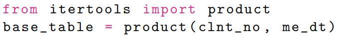

```python
# Itertools generates all possible combinations of these 2 columns and stores as an itertool product.

base_table = product(customer_id, me_dt)
base_table
```

```
<itertools.product at 0x2ca16c6c600>
```

```python
type(base_table)
```

```
itertools.product
```

### 3. Next, you want to convert the itertools.product object base table into a pandas object called base table pd. To do so, use pd.DataFrame.from records and name the columns ’CLNT NO’ and ’ME DT’.

```python
# Pivot_Table to convert the itertool into a pandas DataFrame that is workable.

base_table_pd = pd.DataFrame(base_table,
                             columns = ['customer_id', 'ME DT'])
base_table_pd
```

|  | customer_id | ME DT |
| --- | --- | --- |
| 0 | CS5295 | 2013-02-28 |
| 1 | CS5295 | 2015-03-31 |
| 2 | CS5295 | 2011-11-30 |
| 3 | CS5295 | 2013-11-30 |
| 4 | CS5295 | 2014-03-31 |
| ... | ... | ... |
| 323778 | CS8077 | 2011-08-31 |
| 323779 | CS8077 | 2012-09-30 |
| 323780 | CS8077 | 2014-09-30 |
| 323781 | CS8077 | 2014-02-28 |
| 323782 | CS8077 | 2012-06-30 |

323783 rows × 2 columns

### 4. Finally, you want to validate that you created the table you originally wanted. There are two checks you want to perform:

```
    • Filter client CS1112 and confirm that the dates fall between the min and max month-dates you identified in
      section 1.1. Also, confirm that the snapshot of client CS1112 has 47 rows, one for each month in the dataset.
```

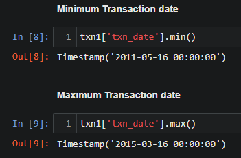

```python
# Tmmporary data for 1 client who has 47 entries

temp = base_table_pd.iloc[:47,:]
temp
```

|  | customer_id | ME DT |
| --- | --- | --- |
| 0 | CS5295 | 2013-02-28 |
| 1 | CS5295 | 2015-03-31 |
| 2 | CS5295 | 2011-11-30 |
| 3 | CS5295 | 2013-11-30 |
| 4 | CS5295 | 2014-03-31 |
| 5 | CS5295 | 2012-02-29 |
| 6 | CS5295 | 2015-01-31 |
| 7 | CS5295 | 2013-01-31 |
| 8 | CS5295 | 2013-08-31 |
| 9 | CS5295 | 2013-07-31 |
| 10 | CS5295 | 2013-03-31 |
| 11 | CS5295 | 2012-11-30 |
| 12 | CS5295 | 2013-05-31 |
| 13 | CS5295 | 2014-12-31 |
| 14 | CS5295 | 2014-01-31 |
| 15 | CS5295 | 2013-12-31 |
| 16 | CS5295 | 2014-07-31 |
| 17 | CS5295 | 2011-07-31 |
| 18 | CS5295 | 2012-03-31 |
| 19 | CS5295 | 2012-01-31 |
| 20 | CS5295 | 2013-04-30 |
| 21 | CS5295 | 2011-10-31 |
| 22 | CS5295 | 2011-12-31 |
| 23 | CS5295 | 2015-02-28 |
| 24 | CS5295 | 2013-10-31 |
| 25 | CS5295 | 2012-12-31 |
| 26 | CS5295 | 2014-05-31 |
| 27 | CS5295 | 2014-11-30 |
| 28 | CS5295 | 2014-04-30 |
| 29 | CS5295 | 2013-06-30 |
| 30 | CS5295 | 2014-06-30 |
| 31 | CS5295 | 2011-06-30 |
| 32 | CS5295 | 2014-08-31 |
| 33 | CS5295 | 2011-09-30 |
| 34 | CS5295 | 2012-05-31 |
| 35 | CS5295 | 2012-04-30 |
| 36 | CS5295 | 2012-08-31 |
| 37 | CS5295 | 2011-05-31 |
| 38 | CS5295 | 2012-07-31 |
| 39 | CS5295 | 2014-10-31 |
| 40 | CS5295 | 2012-10-31 |
| 41 | CS5295 | 2013-09-30 |
| 42 | CS5295 | 2011-08-31 |
| 43 | CS5295 | 2012-09-30 |
| 44 | CS5295 | 2014-09-30 |
| 45 | CS5295 | 2014-02-28 |
| 46 | CS5295 | 2012-06-30 |

```python
# Minimum_ME DT

temp['ME DT'].min()
```

```
Timestamp('2011-05-31 00:00:00')
```

```python
# Maximum_ME DT

temp['ME DT'].max()
```

```
Timestamp('2015-03-31 00:00:00')
```

```
    • Confirm that the base table pd has 323,783 rows, which is the expected value of combinations for 6,889 unique
      clients and 47 unique month-end dates.
```

```python
base_table_pd.count()
```

```
customer_id    323783
ME DT          323783
dtype: int64
```

## 1.5 Create the monthly rolling window features

With the base table pd as a starting point you can convert the irregular transaction data into the typical time series data; data captured at equal intervals. Feature engineering of time series data gives you the potential to build very powerful predictive models.

### 1. Left-join the base table pd with the clnt monthly aggregations table from section 1.3 on [CLNT NO, ME DT] to create the table base clnt mth. Comment on the following questions in Markdown:

```python
base_table_pd
```

|  | customer_id | ME DT |
| --- | --- | --- |
| 0 | CS5295 | 2013-02-28 |
| 1 | CS5295 | 2015-03-31 |
| 2 | CS5295 | 2011-11-30 |
| 3 | CS5295 | 2013-11-30 |
| 4 | CS5295 | 2014-03-31 |
| ... | ... | ... |
| 323778 | CS8077 | 2011-08-31 |
| 323779 | CS8077 | 2012-09-30 |
| 323780 | CS8077 | 2014-09-30 |
| 323781 | CS8077 | 2014-02-28 |
| 323782 | CS8077 | 2012-06-30 |

323783 rows × 2 columns

```python
clnt_monthly_aggregations
```

| customer_id | ME DT | mth_txn_amt_sum | mth_txn_amt_count |
| --- | --- | --- | --- |
| CS1112 | 2011-06-30 | 56 | 1 |
|  | 2011-08-31 | 96 | 1 |
|  | 2011-10-31 | 60 | 1 |
|  | 2012-04-30 | 56 | 1 |
|  | 2012-06-30 | 52 | 1 |
| ... | ... | ... | ... |
| CS9000 | 2014-01-31 | 16 | 1 |
|  | 2014-05-31 | 20 | 1 |
|  | 2014-07-31 | 26 | 1 |
|  | 2014-08-31 | 35 | 1 |
|  | 2015-02-28 | 34 | 1 |

103234 rows × 2 columns

```python
# Using the merge function to left join the client monthly aggregations table to the base table.
# Other functions similar to merge are join and concat but concat is used to add rows and join is used to add columns directly provided they have the same index.

base_clnt_mth = base_table_pd.merge(right = clnt_monthly_aggregations,
                                 how = 'left',
                                 on = ['customer_id', 'ME DT'])
base_clnt_mth
```

|  | customer_id | ME DT | mth_txn_amt_sum | mth_txn_amt_count |
| --- | --- | --- | --- | --- |
| 0 | CS5295 | 2013-02-28 | 35.0 | 1.0 |
| 1 | CS5295 | 2015-03-31 | NaN | NaN |
| 2 | CS5295 | 2011-11-30 | 132.0 | 2.0 |
| 3 | CS5295 | 2013-11-30 | NaN | NaN |
| 4 | CS5295 | 2014-03-31 | NaN | NaN |
| ... | ... | ... | ... | ... |
| 323778 | CS8077 | 2011-08-31 | 30.0 | 1.0 |
| 323779 | CS8077 | 2012-09-30 | NaN | NaN |
| 323780 | CS8077 | 2014-09-30 | NaN | NaN |
| 323781 | CS8077 | 2014-02-28 | NaN | NaN |
| 323782 | CS8077 | 2012-06-30 | NaN | NaN |

323783 rows × 4 columns

```
    • Why do some rows have NaN values?
```

Becasue those values were not pased when the 2 tables kept for matching the merge function thus giving a Nan value for that row

```
    • What values will you choose to impute NaN values in the sum and count columns? Perform the imputation you suggest.
```

I have choosen to do a 0-Value imputation as it makes the most sense, as mentioned in the section above.

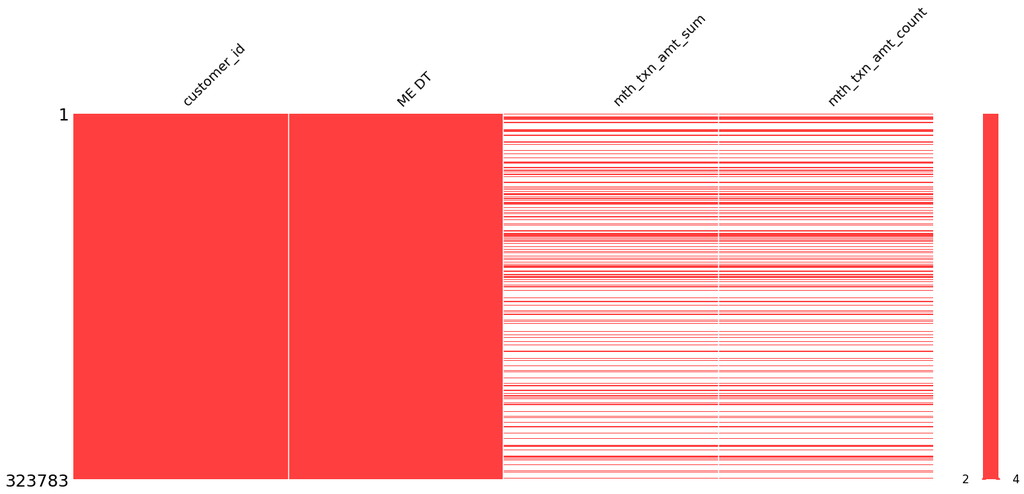

```python
# A library that shows the amount of null values in our DataFrame as a more visual representation.

mno.matrix(base_clnt_mth,
    figsize=(25, 10),
    width_ratios=(20, 1),
    color=(1.00, 0.25, 0.25),
    fontsize=20,
    labels=None,
    label_rotation= 45,
    sparkline=True,
    freq=None,
    ax=None,)
```

```python
# imputena library helps us impute the null values in a very simple way.
# Contains certian functions that can be used to predict and apply recommeded imputation methods.

imp.get_applicable_methods(base_clnt_mth)
```

```
{'constant value substitution',
 'listwise deletion',
 'mice',
 'most-frequent substitution',
 'pairwise deletion',
 'random hot-deck imputation',
 'random sample imputation',
 'srmi',
 'variable deletion'}
```

```python
# Just to check the recommendation and why.

imp.recommend_method(base_clnt_mth)
```

```
'1. The data is a data frame.\n2. You want to apply the same method to the whole data frame.\n3. The data frame contains categorical data.\nTherefore you should apply most-frequent substitution.'
```

```python
# Zero-Value Imputation

imputed_base_clnt_mth = imp.constant_value_imputation(base_clnt_mth, value = 0, inplace = False)
imputed_base_clnt_mth
```

|  | customer_id | ME DT | mth_txn_amt_sum | mth_txn_amt_count |
| --- | --- | --- | --- | --- |
| 0 | CS5295 | 2013-02-28 | 35.0 | 1.0 |
| 1 | CS5295 | 2015-03-31 | 0.0 | 0.0 |
| 2 | CS5295 | 2011-11-30 | 132.0 | 2.0 |
| 3 | CS5295 | 2013-11-30 | 0.0 | 0.0 |
| 4 | CS5295 | 2014-03-31 | 0.0 | 0.0 |
| ... | ... | ... | ... | ... |
| 323778 | CS8077 | 2011-08-31 | 30.0 | 1.0 |
| 323779 | CS8077 | 2012-09-30 | 0.0 | 0.0 |
| 323780 | CS8077 | 2014-09-30 | 0.0 | 0.0 |
| 323781 | CS8077 | 2014-02-28 | 0.0 | 0.0 |
| 323782 | CS8077 | 2012-06-30 | 0.0 | 0.0 |

323783 rows × 4 columns

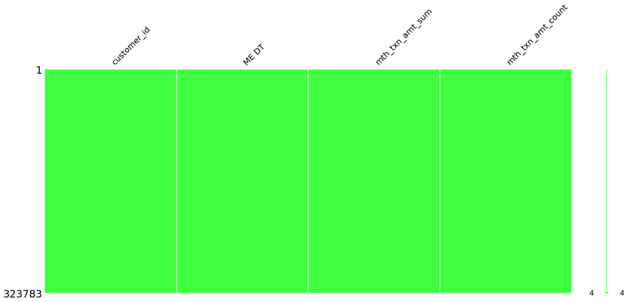

```python
# Final visual representation of the null value table, shows blocks because there are no null values.

mno.matrix(imputed_base_clnt_mth,
    figsize=(25, 10),
    width_ratios=(20, 1),
    color=(0.25, 1.00, 0.25),
    fontsize=20,
    labels=None,
    label_rotation= 45,
    sparkline=True,
    freq=None,
    ax=None,)
```

```
    • Confirm that the number of rows is what you expect. What is the value?
```

```python
imputed_base_clnt_mth.count()
```

```
customer_id          323783
ME DT                323783
mth_txn_amt_sum      323783
mth_txn_amt_count    323783
dtype: int64
```

The value of rows would remain the same in 'Left' merging which is 323783.

```
    • How are tables base clnt mth and clnt monthly aggregations different?
      Comment on the number of rows and the content of each table.
```

```python
base_clnt_mth
```

|  | customer_id | ME DT | mth_txn_amt_sum | mth_txn_amt_count |
| --- | --- | --- | --- | --- |
| 0 | CS5295 | 2013-02-28 | 35.0 | 1.0 |
| 1 | CS5295 | 2015-03-31 | NaN | NaN |
| 2 | CS5295 | 2011-11-30 | 132.0 | 2.0 |
| 3 | CS5295 | 2013-11-30 | NaN | NaN |
| 4 | CS5295 | 2014-03-31 | NaN | NaN |
| ... | ... | ... | ... | ... |
| 323778 | CS8077 | 2011-08-31 | 30.0 | 1.0 |
| 323779 | CS8077 | 2012-09-30 | NaN | NaN |
| 323780 | CS8077 | 2014-09-30 | NaN | NaN |
| 323781 | CS8077 | 2014-02-28 | NaN | NaN |
| 323782 | CS8077 | 2012-06-30 | NaN | NaN |

323783 rows × 4 columns

```python
clnt_monthly_aggregations
```

| customer_id | ME DT | mth_txn_amt_sum | mth_txn_amt_count |
| --- | --- | --- | --- |
| CS1112 | 2011-06-30 | 56 | 1 |
|  | 2011-08-31 | 96 | 1 |
|  | 2011-10-31 | 60 | 1 |
|  | 2012-04-30 | 56 | 1 |
|  | 2012-06-30 | 52 | 1 |
| ... | ... | ... | ... |
| CS9000 | 2014-01-31 | 16 | 1 |
|  | 2014-05-31 | 20 | 1 |
|  | 2014-07-31 | 26 | 1 |
|  | 2014-08-31 | 35 | 1 |
|  | 2015-02-28 | 34 | 1 |

103234 rows × 2 columns

The base client month table has null values, has 323783 rows and all the clients are randomly ordered, whilest in the aggregations table, the index is set to each client's monthly day-to-day and the null values are filled, and has 103234 rows.

This is useful in the merging porcess.

### 2. For the next step, the calculation of the rolling window features, you need to sort the data first by ’CLNT NO’ and then by ’ME DT’ in ascending order. This is necessary to create the order for rolling windows, e.g. 2011-05-31, 2011-06-30, etc.

```python
# Sort the values based on the given column names.

sorted_imputed_base_clnt_mth = imputed_base_clnt_mth.sort_values(by = ['customer_id', 'ME DT'],
                                                                 ascending = True)
sorted_imputed_base_clnt_mth
```

|  | customer_id | ME DT | mth_txn_amt_sum | mth_txn_amt_count |
| --- | --- | --- | --- | --- |
| 157064 | CS1112 | 2011-05-31 | 0.0 | 0.0 |
| 157058 | CS1112 | 2011-06-30 | 56.0 | 1.0 |
| 157044 | CS1112 | 2011-07-31 | 0.0 | 0.0 |
| 157069 | CS1112 | 2011-08-31 | 96.0 | 1.0 |
| 157060 | CS1112 | 2011-09-30 | 0.0 | 0.0 |
| ... | ... | ... | ... | ... |
| 295140 | CS9000 | 2014-11-30 | 0.0 | 0.0 |
| 295126 | CS9000 | 2014-12-31 | 0.0 | 0.0 |
| 295119 | CS9000 | 2015-01-31 | 0.0 | 0.0 |
| 295136 | CS9000 | 2015-02-28 | 34.0 | 1.0 |
| 295114 | CS9000 | 2015-03-31 | 0.0 | 0.0 |

323783 rows × 4 columns

### 3. The idea behind rolling window features is captured in the image below. You calculate some statistical properties (e.g. average) based on a window that is sliding. In the image below, the window is 7 which means that the last 7 points are used at every row to calculate the statistical property.

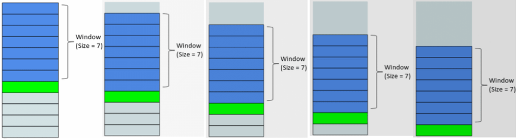

Here, you have to calculate separately the 3, 6 and 12-month rolling window features (tables: rolling features 3M, rolling features 6M, rolling features 12M) for every client that calculates the aggregations ’sum’, mean’ and ’max’ for both columns ’mth txn amt sum’ and ’mth txn cnt’. The steps to achieve this with base clnt mth as the starting dataframe are:

```
        • groupby the client number
        • select the two columns you want to aggregate
        • use the rolling function with the appropriate windows
        • aggregate with ’sum’, 'mean’ and ’max’
```

```python
sorted_imputed_base_clnt_mth
```

|  | customer_id | ME DT | mth_txn_amt_sum | mth_txn_amt_count |
| --- | --- | --- | --- | --- |
| 157064 | CS1112 | 2011-05-31 | 0.0 | 0.0 |
| 157058 | CS1112 | 2011-06-30 | 56.0 | 1.0 |
| 157044 | CS1112 | 2011-07-31 | 0.0 | 0.0 |
| 157069 | CS1112 | 2011-08-31 | 96.0 | 1.0 |
| 157060 | CS1112 | 2011-09-30 | 0.0 | 0.0 |
| ... | ... | ... | ... | ... |
| 295140 | CS9000 | 2014-11-30 | 0.0 | 0.0 |
| 295126 | CS9000 | 2014-12-31 | 0.0 | 0.0 |
| 295119 | CS9000 | 2015-01-31 | 0.0 | 0.0 |
| 295136 | CS9000 | 2015-02-28 | 34.0 | 1.0 |
| 295114 | CS9000 | 2015-03-31 | 0.0 | 0.0 |

323783 rows × 4 columns

```python
import warnings
warnings.filterwarnings('ignore')

rolling_features_3M = sorted_imputed_base_clnt_mth.groupby(['customer_id'])["mth_txn_amt_sum",
                                                                            "mth_txn_amt_count"].rolling(3).agg({k : ['sum', 'mean', 'max']
                                                                                                                 for k in ['mth_txn_amt_sum',
                                                                                                                           'mth_txn_amt_count']})

rolling_features_6M = sorted_imputed_base_clnt_mth.groupby(['customer_id'])["mth_txn_amt_sum",
                                                                            "mth_txn_amt_count"].rolling(6).agg({k : ['sum', 'mean', 'max']
                                                                                                                 for k in ['mth_txn_amt_sum',
                                                                                                                           'mth_txn_amt_count']})

rolling_features_9M = sorted_imputed_base_clnt_mth.groupby(['customer_id'])["mth_txn_amt_sum",
                                                                            "mth_txn_amt_count"].rolling(9).agg({k : ['sum', 'mean', 'max']
                                                                                                                 for k in ['mth_txn_amt_sum',
                                                                                                                           'mth_txn_amt_count']})
```

```python
rolling_features_3M
```

| customer_id |  | mth_txn_amt_sum sum | mth_txn_amt_sum mean | mth_txn_amt_sum max | mth_txn_amt_count sum | mth_txn_amt_count mean | mth_txn_amt_count max |
| --- | --- | --- | --- | --- | --- | --- | --- |
| CS1112 | 157064 | NaN | NaN | NaN | NaN | NaN | NaN |
|  | 157058 | NaN | NaN | NaN | NaN | NaN | NaN |
|  | 157044 | 56.0 | 18.666667 | 56.0 | 1.0 | 0.333333 | 1.0 |
|  | 157069 | 152.0 | 50.666667 | 96.0 | 2.0 | 0.666667 | 1.0 |
|  | 157060 | 96.0 | 32.000000 | 96.0 | 1.0 | 0.333333 | 1.0 |
| ... | ... | ... | ... | ... | ... | ... | ... |
| CS9000 | 295140 | 0.0 | 0.000000 | 0.0 | 0.0 | 0.000000 | 0.0 |
|  | 295126 | 0.0 | 0.000000 | 0.0 | 0.0 | 0.000000 | 0.0 |
|  | 295119 | 0.0 | 0.000000 | 0.0 | 0.0 | 0.000000 | 0.0 |
|  | 295136 | 34.0 | 11.333333 | 34.0 | 1.0 | 0.333333 | 1.0 |
|  | 295114 | 34.0 | 11.333333 | 34.0 | 1.0 | 0.333333 | 1.0 |

323783 rows × 6 columns

The output of the 3-month rolling window dataframe is shown below. Also, answer the following questions in the .ipynb notebook as Markdown comments.

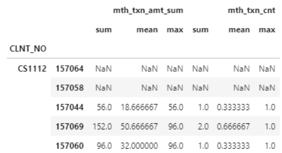

```
    • How many rows appear with NaN values at the beginning of each client for 3, 6 and 12-month windows, respectively?
      Why do they appear?
```

Because these are rolling features, thus, they actually take the value(mentioned) and find the answer and store it in the last row.

i.e. Thus for rolling features with 3 rows, the first 2 rows are NaN because they don't have values above them.

Same is the case for the rolling features with 6 and with 9 rows.

```
    • How many levels do the index and columns have? Are these MultiIndex dataframes?
```

They both, index and columns, have 2 index levels.

Yes, they are MultiIndex Dataframes.

```python
rolling_features_3M.index.nlevels
```

```
2
```

```python
rolling_features_3M.index
```

```
MultiIndex([('CS1112', 157064),
            ('CS1112', 157058),
            ('CS1112', 157044),
            ('CS1112', 157069),
            ('CS1112', 157060),
            ('CS1112', 157048),
            ('CS1112', 157029),
            ('CS1112', 157049),
            ('CS1112', 157046),
            ('CS1112', 157032),
            ...
            ('CS9000', 295143),
            ('CS9000', 295129),
            ('CS9000', 295145),
            ('CS9000', 295157),
            ('CS9000', 295152),
            ('CS9000', 295140),
            ('CS9000', 295126),
            ('CS9000', 295119),
            ('CS9000', 295136),
            ('CS9000', 295114)],
           names=['customer_id', None], length=323783)
```

```python
rolling_features_3M.columns.nlevels
```

```
2
```

```python
rolling_features_3M.columns
```

```
MultiIndex([(  'mth_txn_amt_sum',  'sum'),
            (  'mth_txn_amt_sum', 'mean'),
            (  'mth_txn_amt_sum',  'max'),
            ('mth_txn_amt_count',  'sum'),
            ('mth_txn_amt_count', 'mean'),
            ('mth_txn_amt_count',  'max')],
           )
```

```
    • Rename the columns as following: ’amt sum 3M’, ’amt mean 3M’, ’amt max 3M’, ’txn cnt sum 3M’, ’txn cnt mean 3M’,
      ’txn cnt max 3M’ and follow the same naming convention for 6M and 12M.
```

```python
# Rename function used to rename the MultiLevel Index using the function sttributes.

rolling_features_3M = rolling_features_3M.rename(columns = {'sum':'amt sum 3M',
                                                            'mean':'amt mean 3M',
                                                            'max':'amt max 3M',
                                                            'sum':'txn cnt sum 3M',
                                                            'mean':'txn cnt mean 3M',
                                                            'max':'txn cnt max 3M',}, level=1).droplevel(0, axis = 1).droplevel(0, axis = 0)

rolling_features_6M = rolling_features_6M.rename(columns = {'sum':'amt sum 6M',
                                                            'mean':'amt mean 6M',
                                                            'max':'amt max 6M',
                                                            'sum':'txn cnt sum 6M',
                                                            'mean':'txn cnt mean 6M',
                                                            'max':'txn cnt max 6M',}, level=1).droplevel(0, axis = 1).droplevel(0, axis = 0)

rolling_features_9M = rolling_features_9M.rename(columns = {'sum':'amt sum 9M',
                                                            'mean':'amt mean 9M',
                                                            'max':'amt max 9M',
                                                            'sum':'txn cnt sum 9M',
                                                            'mean':'txn cnt mean 9M',
                                                            'max':'txn cnt max 9M',}, level=1).droplevel(0, axis = 1).droplevel(0, axis = 0)
```

### 4. Merge the 4 tables: base clnt mth, rolling features 3M, rolling features 6M, rolling features 12M in the output all rolling features. It is recommended to drop the level:0 of the rolling features MultiIndex table and join with base clnt mth on the indexes.

#### Make sure you understand why joining on the indexes preserves the CLNT NO and ME DT for each index.

```python
# Join function used here as mentioned previously to join the columns of the other 3 tables into the base table based on the index.

all_rolling_features = sorted_imputed_base_clnt_mth.join(rolling_features_3M).join(rolling_features_6M).join(rolling_features_9M)
all_rolling_features
```

|  | customer_id | ME DT | mth_txn_amt_sum | mth_txn_amt_count | txn cnt sum 3M | txn cnt mean 3M | txn cnt max 3M | txn cnt sum 3M | txn cnt mean 3M | txn cnt max 3M | ... | txn cnt max 6M | txn cnt sum 6M | txn cnt mean 6M | txn cnt max 6M | txn cnt sum 9M | txn cnt mean 9M | txn cnt max 9M | txn cnt sum 9M | txn cnt mean 9M | txn cnt max 9M |
| --- | --- | --- | --- | --- | --- | --- | --- | --- | --- | --- | --- | --- | --- | --- | --- | --- | --- | --- | --- | --- | --- |
| 157064 | CS1112 | 2011-05-31 | 0.0 | 0.0 | NaN | NaN | NaN | NaN | NaN | NaN | ... | NaN | NaN | NaN | NaN | NaN | NaN | NaN | NaN | NaN | NaN |
| 157058 | CS1112 | 2011-06-30 | 56.0 | 1.0 | NaN | NaN | NaN | NaN | NaN | NaN | ... | NaN | NaN | NaN | NaN | NaN | NaN | NaN | NaN | NaN | NaN |
| 157044 | CS1112 | 2011-07-31 | 0.0 | 0.0 | 56.0 | 18.666667 | 56.0 | 1.0 | 0.333333 | 1.0 | ... | NaN | NaN | NaN | NaN | NaN | NaN | NaN | NaN | NaN | NaN |
| 157069 | CS1112 | 2011-08-31 | 96.0 | 1.0 | 152.0 | 50.666667 | 96.0 | 2.0 | 0.666667 | 1.0 | ... | NaN | NaN | NaN | NaN | NaN | NaN | NaN | NaN | NaN | NaN |
| 157060 | CS1112 | 2011-09-30 | 0.0 | 0.0 | 96.0 | 32.000000 | 96.0 | 1.0 | 0.333333 | 1.0 | ... | NaN | NaN | NaN | NaN | NaN | NaN | NaN | NaN | NaN | NaN |
| ... | ... | ... | ... | ... | ... | ... | ... | ... | ... | ... | ... | ... | ... | ... | ... | ... | ... | ... | ... | ... | ... |
| 295140 | CS9000 | 2014-11-30 | 0.0 | 0.0 | 0.0 | 0.000000 | 0.0 | 0.0 | 0.000000 | 0.0 | ... | 35.0 | 2.0 | 0.333333 | 1.0 | 81.0 | 9.000000 | 35.0 | 3.0 | 0.333333 | 1.0 |
| 295126 | CS9000 | 2014-12-31 | 0.0 | 0.0 | 0.0 | 0.000000 | 0.0 | 0.0 | 0.000000 | 0.0 | ... | 35.0 | 2.0 | 0.333333 | 1.0 | 81.0 | 9.000000 | 35.0 | 3.0 | 0.333333 | 1.0 |
| 295119 | CS9000 | 2015-01-31 | 0.0 | 0.0 | 0.0 | 0.000000 | 0.0 | 0.0 | 0.000000 | 0.0 | ... | 35.0 | 1.0 | 0.166667 | 1.0 | 81.0 | 9.000000 | 35.0 | 3.0 | 0.333333 | 1.0 |
| 295136 | CS9000 | 2015-02-28 | 34.0 | 1.0 | 34.0 | 11.333333 | 34.0 | 1.0 | 0.333333 | 1.0 | ... | 34.0 | 1.0 | 0.166667 | 1.0 | 95.0 | 10.555556 | 35.0 | 3.0 | 0.333333 | 1.0 |
| 295114 | CS9000 | 2015-03-31 | 0.0 | 0.0 | 34.0 | 11.333333 | 34.0 | 1.0 | 0.333333 | 1.0 | ... | 34.0 | 1.0 | 0.166667 | 1.0 | 95.0 | 10.555556 | 35.0 | 3.0 | 0.333333 | 1.0 |

323783 rows × 22 columns

### 5. Confirm that your final output all rolling features has 323,783 rows and 22 columns and save it as mth rolling features.xlsx.

```python
all_rolling_features.shape
```

```
(323783, 22)
```

```python
all_rolling_features.to_excel('mth_rolling_features.xlsx')
```

## 1.6 Date-related features: date of the week

#### In this section, you will create the date-related features that capture information about the day of the week the transactions were performed.

### 1. The DatetimeIndex object you used earlier allows you to extract many components of a DateTime object. Here, you want to use the attributes dt.dayofweek and/or dt.day name() to extract the day of the week from column ’txn date’ of the txn table (with Monday=0, Sunday=6). The expected output below shows both columns.

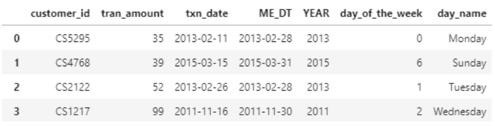

```python
txn1[['day_of_the_week', 'day_name']] = ""
txn1['day_of_the_week'] = txn1['txn_date'].dt.dayofweek
txn1['day_name'] = txn1['txn_date'].dt.day_name()
txn1
```

|  | customer_id | tran_amount | txn_date | ME DT | YEAR | day_of_the_week | day_name |
| --- | --- | --- | --- | --- | --- | --- | --- |
| 0 | CS5295 | 35 | 2013-02-11 | 2013-02-28 | 2013 | 0 | Monday |
| 1 | CS4768 | 39 | 2015-03-15 | 2015-03-31 | 2015 | 6 | Sunday |
| 2 | CS2122 | 52 | 2013-02-26 | 2013-02-28 | 2013 | 1 | Tuesday |
| 3 | CS1217 | 99 | 2011-11-16 | 2011-11-30 | 2011 | 2 | Wednesday |
| 4 | CS1850 | 78 | 2013-11-20 | 2013-11-30 | 2013 | 2 | Wednesday |
| ... | ... | ... | ... | ... | ... | ... | ... |
| 124995 | CS8433 | 64 | 2011-06-26 | 2011-06-30 | 2011 | 6 | Sunday |
| 124996 | CS7232 | 38 | 2014-08-19 | 2014-08-31 | 2014 | 1 | Tuesday |
| 124997 | CS8731 | 42 | 2014-11-28 | 2014-11-30 | 2014 | 4 | Friday |
| 124998 | CS8133 | 13 | 2013-12-14 | 2013-12-31 | 2013 | 5 | Saturday |
| 124999 | CS7996 | 36 | 2014-12-13 | 2014-12-31 | 2014 | 5 | Saturday |

125000 rows × 7 columns

```python
transactions_count = txn1[['txn_date', 'day_of_the_week']].value_counts()
transactions_count
```

```
txn_date    day_of_the_week
2011-07-16  5                  141
2014-04-15  1                  124
2011-09-18  6                  124
2011-08-11  3                  122
2013-04-19  4                  121
                              ...
2015-01-18  6                   63
2013-12-04  2                   62
2012-08-18  5                   60
2015-01-17  5                   58
2014-02-26  2                   55
Length: 1401, dtype: int64
```

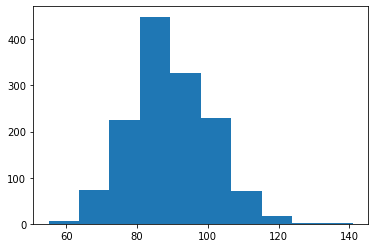

```python
plt.hist(transactions_count)
```

### 3. Following the same logic as in section 1.2, generate the features that capture the count of transactions per client, year and day of the week. The intermediate MultiIndex dataframe (with nlevels=3) and the final pivoted output with a single index are shown in the snapshots below.

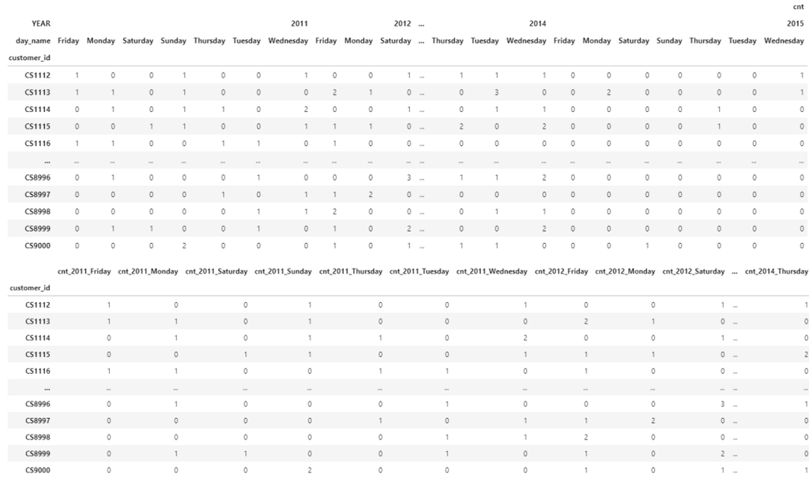

```python
ann_day_count = pd.NamedAgg(column = "tran_amount", aggfunc = 'count')

annual_day_of_week_counts = txn1.groupby(['customer_id',
                                          'YEAR',
                                          'day_name']).agg(ann_day_of_week_count = ann_day_count)
annual_day_of_week_counts
```

| customer_id | YEAR | day_name | ann_day_of_week_count |
| --- | --- | --- | --- |
| CS1112 | 2011 | Friday | 1 |
|  |  | Sunday | 1 |
|  |  | Wednesday | 1 |
|  | 2012 | Saturday | 1 |
|  |  | Sunday | 3 |
| ... | ... | ... | ... |
| CS9000 | 2013 | Tuesday | 1 |
|  | 2014 | Sunday | 2 |
|  |  | Thursday | 1 |
|  |  | Tuesday | 1 |
|  | 2015 | Saturday | 1 |

93736 rows × 1 columns

```python
# Imputation same as before, 0-Value

annual_day_of_week_counts_pt = pd.pivot_table(annual_day_of_week_counts,
                                             index = 'customer_id',
                                             columns = ['YEAR', 'day_name'],
                                             fill_value = 0)                 # 0-Value Imputation
annual_day_of_week_counts_pt
```

| YEAR day_name customer_id | ann_day_of_week_count 2011 Friday | ann_day_of_week_count 2011 Monday | ann_day_of_week_count 2011 Saturday | ann_day_of_week_count 2011 Sunday | ann_day_of_week_count 2011 Thursday | ann_day_of_week_count 2011 Tuesday | ann_day_of_week_count 2011 Wednesday | ann_day_of_week_count 2012 Friday | ann_day_of_week_count 2012 Monday | ann_day_of_week_count 2012 Saturday | ann_day_of_week_count ... | ann_day_of_week_count 2014 Thursday | ann_day_of_week_count 2014 Tuesday | ann_day_of_week_count 2014 Wednesday | ann_day_of_week_count 2015 Friday | ann_day_of_week_count 2015 Monday | ann_day_of_week_count 2015 Saturday | ann_day_of_week_count 2015 Sunday | ann_day_of_week_count 2015 Thursday | ann_day_of_week_count 2015 Tuesday | ann_day_of_week_count 2015 Wednesday |
| --- | --- | --- | --- | --- | --- | --- | --- | --- | --- | --- | --- | --- | --- | --- | --- | --- | --- | --- | --- | --- | --- |
| CS1112 | 1 | 0 | 0 | 1 | 0 | 0 | 1 | 0 | 0 | 1 | ... | 1 | 1 | 1 | 0 | 0 | 0 | 0 | 0 | 0 | 1 |
| CS1113 | 1 | 1 | 0 | 1 | 0 | 0 | 0 | 2 | 1 | 0 | ... | 0 | 3 | 0 | 0 | 2 | 0 | 0 | 0 | 0 | 1 |
| CS1114 | 0 | 1 | 0 | 1 | 1 | 0 | 2 | 0 | 0 | 1 | ... | 0 | 1 | 1 | 0 | 0 | 0 | 0 | 1 | 0 | 0 |
| CS1115 | 0 | 0 | 1 | 1 | 0 | 0 | 1 | 1 | 1 | 0 | ... | 2 | 0 | 2 | 0 | 0 | 0 | 0 | 1 | 0 | 0 |
| CS1116 | 1 | 1 | 0 | 0 | 1 | 1 | 0 | 1 | 0 | 0 | ... | 0 | 0 | 0 | 0 | 0 | 0 | 0 | 0 | 0 | 0 |
| ... | ... | ... | ... | ... | ... | ... | ... | ... | ... | ... | ... | ... | ... | ... | ... | ... | ... | ... | ... | ... | ... |
| CS8996 | 0 | 1 | 0 | 0 | 0 | 1 | 0 | 0 | 0 | 3 | ... | 1 | 1 | 2 | 0 | 0 | 0 | 0 | 0 | 0 | 0 |
| CS8997 | 0 | 0 | 0 | 0 | 1 | 0 | 1 | 1 | 2 | 0 | ... | 0 | 0 | 0 | 0 | 0 | 0 | 0 | 0 | 0 | 0 |
| CS8998 | 0 | 0 | 0 | 0 | 0 | 1 | 1 | 2 | 0 | 0 | ... | 0 | 1 | 1 | 0 | 0 | 0 | 0 | 0 | 0 | 0 |
| CS8999 | 0 | 1 | 1 | 0 | 0 | 1 | 0 | 1 | 0 | 2 | ... | 0 | 0 | 2 | 0 | 0 | 0 | 0 | 0 | 0 | 0 |
| CS9000 | 0 | 0 | 0 | 2 | 0 | 0 | 0 | 1 | 0 | 1 | ... | 1 | 1 | 0 | 0 | 0 | 1 | 0 | 0 | 0 | 0 |

6889 rows × 35 columns

```python
annual_day_of_week_counts_pt.columns.nlevels
```

```
3
```

```python
annual_day_of_week_counts_pt.columns
```

```
MultiIndex([('ann_day_of_week_count', 2011,    'Friday'),
            ('ann_day_of_week_count', 2011,    'Monday'),
            ('ann_day_of_week_count', 2011,  'Saturday'),
            ('ann_day_of_week_count', 2011,    'Sunday'),
            ('ann_day_of_week_count', 2011,  'Thursday'),
            ('ann_day_of_week_count', 2011,   'Tuesday'),
            ('ann_day_of_week_count', 2011, 'Wednesday'),
            ('ann_day_of_week_count', 2012,    'Friday'),
            ('ann_day_of_week_count', 2012,    'Monday'),
            ('ann_day_of_week_count', 2012,  'Saturday'),
            ('ann_day_of_week_count', 2012,    'Sunday'),
            ('ann_day_of_week_count', 2012,  'Thursday'),
            ('ann_day_of_week_count', 2012,   'Tuesday'),
            ('ann_day_of_week_count', 2012, 'Wednesday'),
            ('ann_day_of_week_count', 2013,    'Friday'),
            ('ann_day_of_week_count', 2013,    'Monday'),
            ('ann_day_of_week_count', 2013,  'Saturday'),
            ('ann_day_of_week_count', 2013,    'Sunday'),
            ('ann_day_of_week_count', 2013,  'Thursday'),
            ('ann_day_of_week_count', 2013,   'Tuesday'),
            ('ann_day_of_week_count', 2013, 'Wednesday'),
            ('ann_day_of_week_count', 2014,    'Friday'),
            ('ann_day_of_week_count', 2014,    'Monday'),
            ('ann_day_of_week_count', 2014,  'Saturday'),
            ('ann_day_of_week_count', 2014,    'Sunday'),
            ('ann_day_of_week_count', 2014,  'Thursday'),
            ('ann_day_of_week_count', 2014,   'Tuesday'),
            ('ann_day_of_week_count', 2014, 'Wednesday'),
            ('ann_day_of_week_count', 2015,    'Friday'),
            ('ann_day_of_week_count', 2015,    'Monday'),
            ('ann_day_of_week_count', 2015,  'Saturday'),
            ('ann_day_of_week_count', 2015,    'Sunday'),
            ('ann_day_of_week_count', 2015,  'Thursday'),
            ('ann_day_of_week_count', 2015,   'Tuesday'),
            ('ann_day_of_week_count', 2015, 'Wednesday')],
           names=[None, 'YEAR', 'day_name'])
```

```python
cnt_level_0 = annual_day_of_week_counts_pt.columns.get_level_values(0).astype (str)
cnt_level_1 = annual_day_of_week_counts_pt.columns.get_level_values(1).astype (str)
cnt_level_2 = annual_day_of_week_counts_pt.columns.get_level_values(2).astype (str)
annual_day_of_week_counts_pt.columns = cnt_level_0 + '_' + cnt_level_1 + '_' + cnt_level_2
annual_day_of_week_counts_pt
```

| customer_id | ann_day_of_week_count_2011_Friday | ann_day_of_week_count_2011_Monday | ann_day_of_week_count_2011_Saturday | ann_day_of_week_count_2011_Sunday | ann_day_of_week_count_2011_Thursday | ann_day_of_week_count_2011_Tuesday | ann_day_of_week_count_2011_Wednesday | ann_day_of_week_count_2012_Friday | ann_day_of_week_count_2012_Monday | ann_day_of_week_count_2012_Saturday | ... | ann_day_of_week_count_2014_Thursday | ann_day_of_week_count_2014_Tuesday | ann_day_of_week_count_2014_Wednesday | ann_day_of_week_count_2015_Friday | ann_day_of_week_count_2015_Monday | ann_day_of_week_count_2015_Saturday | ann_day_of_week_count_2015_Sunday | ann_day_of_week_count_2015_Thursday | ann_day_of_week_count_2015_Tuesday | ann_day_of_week_count_2015_Wednesday |
| --- | --- | --- | --- | --- | --- | --- | --- | --- | --- | --- | --- | --- | --- | --- | --- | --- | --- | --- | --- | --- | --- |
| CS1112 | 1 | 0 | 0 | 1 | 0 | 0 | 1 | 0 | 0 | 1 | ... | 1 | 1 | 1 | 0 | 0 | 0 | 0 | 0 | 0 | 1 |
| CS1113 | 1 | 1 | 0 | 1 | 0 | 0 | 0 | 2 | 1 | 0 | ... | 0 | 3 | 0 | 0 | 2 | 0 | 0 | 0 | 0 | 1 |
| CS1114 | 0 | 1 | 0 | 1 | 1 | 0 | 2 | 0 | 0 | 1 | ... | 0 | 1 | 1 | 0 | 0 | 0 | 0 | 1 | 0 | 0 |
| CS1115 | 0 | 0 | 1 | 1 | 0 | 0 | 1 | 1 | 1 | 0 | ... | 2 | 0 | 2 | 0 | 0 | 0 | 0 | 1 | 0 | 0 |
| CS1116 | 1 | 1 | 0 | 0 | 1 | 1 | 0 | 1 | 0 | 0 | ... | 0 | 0 | 0 | 0 | 0 | 0 | 0 | 0 | 0 | 0 |
| ... | ... | ... | ... | ... | ... | ... | ... | ... | ... | ... | ... | ... | ... | ... | ... | ... | ... | ... | ... | ... | ... |
| CS8996 | 0 | 1 | 0 | 0 | 0 | 1 | 0 | 0 | 0 | 3 | ... | 1 | 1 | 2 | 0 | 0 | 0 | 0 | 0 | 0 | 0 |
| CS8997 | 0 | 0 | 0 | 0 | 1 | 0 | 1 | 1 | 2 | 0 | ... | 0 | 0 | 0 | 0 | 0 | 0 | 0 | 0 | 0 | 0 |
| CS8998 | 0 | 0 | 0 | 0 | 0 | 1 | 1 | 2 | 0 | 0 | ... | 0 | 1 | 1 | 0 | 0 | 0 | 0 | 0 | 0 | 0 |
| CS8999 | 0 | 1 | 1 | 0 | 0 | 1 | 0 | 1 | 0 | 2 | ... | 0 | 0 | 2 | 0 | 0 | 0 | 0 | 0 | 0 | 0 |
| CS9000 | 0 | 0 | 0 | 2 | 0 | 0 | 0 | 1 | 0 | 1 | ... | 1 | 1 | 0 | 0 | 0 | 1 | 0 | 0 | 0 | 0 |

6889 rows × 35 columns

### 4. Confirm that your output has the same number of rows as the final output in section 1.2 and save it as annual day of week counts pivot.xlsx. How many features/columns did you create in this section?

```python
# Annual Day of Week Count = 6889

annual_day_of_week_counts_pt.shape
```

```
(6889, 35)
```

```python
# Client Annual Aggregation count = 6889

clnt_annual_aggregations_pt.shape
```

```
(6889, 40)
```

```python
annual_day_of_week_counts_pt.to_excel('annual_day_of_week_counts_pivot.xlsx')
```

### 5. Similarly, generate the features that capture the count of transactions per client, month-end-date and day of the week. In contrast with the annual pivot table in the previous step, here you want to create the pivot with [’customer id’, ’ME DT’] as index to obtain the following output dataframe.

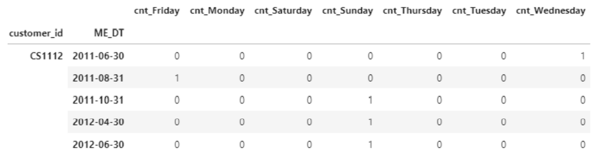

```python
txn1
```

|  | customer_id | tran_amount | txn_date | ME DT | YEAR | day_of_the_week | day_name |
| --- | --- | --- | --- | --- | --- | --- | --- |
| 0 | CS5295 | 35 | 2013-02-11 | 2013-02-28 | 2013 | 0 | Monday |
| 1 | CS4768 | 39 | 2015-03-15 | 2015-03-31 | 2015 | 6 | Sunday |
| 2 | CS2122 | 52 | 2013-02-26 | 2013-02-28 | 2013 | 1 | Tuesday |
| 3 | CS1217 | 99 | 2011-11-16 | 2011-11-30 | 2011 | 2 | Wednesday |
| 4 | CS1850 | 78 | 2013-11-20 | 2013-11-30 | 2013 | 2 | Wednesday |
| ... | ... | ... | ... | ... | ... | ... | ... |
| 124995 | CS8433 | 64 | 2011-06-26 | 2011-06-30 | 2011 | 6 | Sunday |
| 124996 | CS7232 | 38 | 2014-08-19 | 2014-08-31 | 2014 | 1 | Tuesday |
| 124997 | CS8731 | 42 | 2014-11-28 | 2014-11-30 | 2014 | 4 | Friday |
| 124998 | CS8133 | 13 | 2013-12-14 | 2013-12-31 | 2013 | 5 | Saturday |
| 124999 | CS7996 | 36 | 2014-12-13 | 2014-12-31 | 2014 | 5 | Saturday |

125000 rows × 7 columns

```python
ann_MEDT_count = pd.NamedAgg(column = "tran_amount", aggfunc = 'count')

annual_ME_DT_counts = txn1.groupby(['customer_id',
                                          'ME DT',
                                          'day_name']).agg(ann_day_of_week_count = ann_MEDT_count)
annual_ME_DT_counts
```

| customer_id | ME DT | day_name | ann_day_of_week_count |
| --- | --- | --- | --- |
| CS1112 | 2011-06-30 | Wednesday | 1 |
|  | 2011-08-31 | Friday | 1 |
|  | 2011-10-31 | Sunday | 1 |
|  | 2012-04-30 | Sunday | 1 |
|  | 2012-06-30 | Sunday | 1 |
| ... | ... | ... | ... |
| CS9000 | 2014-01-31 | Sunday | 1 |
|  | 2014-05-31 | Thursday | 1 |
|  | 2014-07-31 | Tuesday | 1 |
|  | 2014-08-31 | Sunday | 1 |
|  | 2015-02-28 | Saturday | 1 |

121512 rows × 1 columns

```python
# Imputation same as before, 0-Value

annual_ME_DT_counts_pt = pd.pivot_table(annual_ME_DT_counts,
                                             index = ['customer_id', 'ME DT'],
                                             columns = 'day_name',
                                             fill_value = 0)                  # 0-Value Imputation
annual_ME_DT_counts_pt
```

| customer_id | day_name ME DT | ann_day_of_week_count Friday | ann_day_of_week_count Monday | ann_day_of_week_count Saturday | ann_day_of_week_count Sunday | ann_day_of_week_count Thursday | ann_day_of_week_count Tuesday | ann_day_of_week_count Wednesday |
| --- | --- | --- | --- | --- | --- | --- | --- | --- |
| CS1112 | 2011-06-30 | 0 | 0 | 0 | 0 | 0 | 0 | 1 |
|  | 2011-08-31 | 1 | 0 | 0 | 0 | 0 | 0 | 0 |
|  | 2011-10-31 | 0 | 0 | 0 | 1 | 0 | 0 | 0 |
|  | 2012-04-30 | 0 | 0 | 0 | 1 | 0 | 0 | 0 |
|  | 2012-06-30 | 0 | 0 | 0 | 1 | 0 | 0 | 0 |
| ... | ... | ... | ... | ... | ... | ... | ... | ... |
| CS9000 | 2014-01-31 | 0 | 0 | 0 | 1 | 0 | 0 | 0 |
|  | 2014-05-31 | 0 | 0 | 0 | 0 | 1 | 0 | 0 |
|  | 2014-07-31 | 0 | 0 | 0 | 0 | 0 | 1 | 0 |
|  | 2014-08-31 | 0 | 0 | 0 | 1 | 0 | 0 | 0 |
|  | 2015-02-28 | 0 | 0 | 1 | 0 | 0 | 0 | 0 |

103234 rows × 7 columns

```python
annual_ME_DT_counts_pt.columns.nlevels
```

```
2
```

```python
annual_ME_DT_counts_pt.columns
```

```
MultiIndex([('ann_day_of_week_count',    'Friday'),
            ('ann_day_of_week_count',    'Monday'),
            ('ann_day_of_week_count',  'Saturday'),
            ('ann_day_of_week_count',    'Sunday'),
            ('ann_day_of_week_count',  'Thursday'),
            ('ann_day_of_week_count',   'Tuesday'),
            ('ann_day_of_week_count', 'Wednesday')],
           names=[None, 'day_name'])
```

```python
me_cnt_level_0 = annual_ME_DT_counts_pt.columns.get_level_values(0).astype (str)
me_cnt_level_1 = annual_ME_DT_counts_pt.columns.get_level_values(1).astype (str)

annual_ME_DT_counts_pt.columns = me_cnt_level_0 + '_' + me_cnt_level_1
annual_ME_DT_counts_pt
```

| customer_id | ME DT | ann_day_of_week_count_Friday | ann_day_of_week_count_Monday | ann_day_of_week_count_Saturday | ann_day_of_week_count_Sunday | ann_day_of_week_count_Thursday | ann_day_of_week_count_Tuesday | ann_day_of_week_count_Wednesday |
| --- | --- | --- | --- | --- | --- | --- | --- | --- |
| CS1112 | 2011-06-30 | 0 | 0 | 0 | 0 | 0 | 0 | 1 |
|  | 2011-08-31 | 1 | 0 | 0 | 0 | 0 | 0 | 0 |
|  | 2011-10-31 | 0 | 0 | 0 | 1 | 0 | 0 | 0 |
|  | 2012-04-30 | 0 | 0 | 0 | 1 | 0 | 0 | 0 |
|  | 2012-06-30 | 0 | 0 | 0 | 1 | 0 | 0 | 0 |
| ... | ... | ... | ... | ... | ... | ... | ... | ... |
| CS9000 | 2014-01-31 | 0 | 0 | 0 | 1 | 0 | 0 | 0 |
|  | 2014-05-31 | 0 | 0 | 0 | 0 | 1 | 0 | 0 |
|  | 2014-07-31 | 0 | 0 | 0 | 0 | 0 | 1 | 0 |
|  | 2014-08-31 | 0 | 0 | 0 | 1 | 0 | 0 | 0 |
|  | 2015-02-28 | 0 | 0 | 1 | 0 | 0 | 0 | 0 |

103234 rows × 7 columns

### 6. Join with base table pd as you did in section 1.5 and impute with your choice of value for NaN. Save the final output as mth day counts.xlxs.

```python
mth_day_counts = base_table_pd.merge(right = annual_ME_DT_counts_pt,
                                 how = 'left',
                                 on = ['customer_id', 'ME DT'])
mth_day_counts
```

|  | customer_id | ME DT | ann_day_of_week_count_Friday | ann_day_of_week_count_Monday | ann_day_of_week_count_Saturday | ann_day_of_week_count_Sunday | ann_day_of_week_count_Thursday | ann_day_of_week_count_Tuesday | ann_day_of_week_count_Wednesday |
| --- | --- | --- | --- | --- | --- | --- | --- | --- | --- |
| 0 | CS5295 | 2013-02-28 | 0.0 | 1.0 | 0.0 | 0.0 | 0.0 | 0.0 | 0.0 |
| 1 | CS5295 | 2015-03-31 | NaN | NaN | NaN | NaN | NaN | NaN | NaN |
| 2 | CS5295 | 2011-11-30 | 0.0 | 1.0 | 0.0 | 0.0 | 0.0 | 0.0 | 1.0 |
| 3 | CS5295 | 2013-11-30 | NaN | NaN | NaN | NaN | NaN | NaN | NaN |
| 4 | CS5295 | 2014-03-31 | NaN | NaN | NaN | NaN | NaN | NaN | NaN |
| ... | ... | ... | ... | ... | ... | ... | ... | ... | ... |
| 323778 | CS8077 | 2011-08-31 | 0.0 | 0.0 | 0.0 | 1.0 | 0.0 | 0.0 | 0.0 |
| 323779 | CS8077 | 2012-09-30 | NaN | NaN | NaN | NaN | NaN | NaN | NaN |
| 323780 | CS8077 | 2014-09-30 | NaN | NaN | NaN | NaN | NaN | NaN | NaN |
| 323781 | CS8077 | 2014-02-28 | NaN | NaN | NaN | NaN | NaN | NaN | NaN |
| 323782 | CS8077 | 2012-06-30 | NaN | NaN | NaN | NaN | NaN | NaN | NaN |

323783 rows × 9 columns

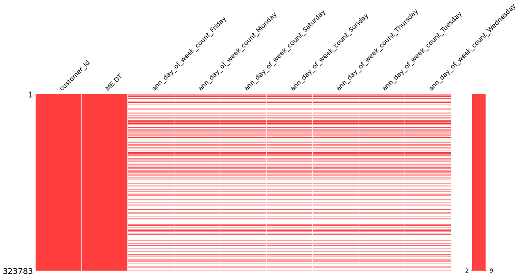

```python
mno.matrix(mth_day_counts,
    figsize=(25, 10),
    width_ratios=(20, 1),
    color=(1.00, 0.25, 0.25),
    fontsize=20,
    labels=None,
    label_rotation= 45,
    sparkline=True,
    freq=None,
    ax=None,)
```

```python
imp.get_applicable_methods(mth_day_counts)
```

```
{'constant value substitution',
 'listwise deletion',
 'mice',
 'most-frequent substitution',
 'pairwise deletion',
 'random hot-deck imputation',
 'random sample imputation',
 'srmi',
 'variable deletion'}
```

```python
imp.recommend_method(mth_day_counts)
```

```
'1. The data is a data frame.\n2. You want to apply the same method to the whole data frame.\n3. The data frame contains categorical data.\nTherefore you should apply most-frequent substitution.'
```

```python
# 0-Value Imputation

fnl_mth_day_counts = imp.constant_value_imputation(mth_day_counts, value = 0, inplace = False)
```

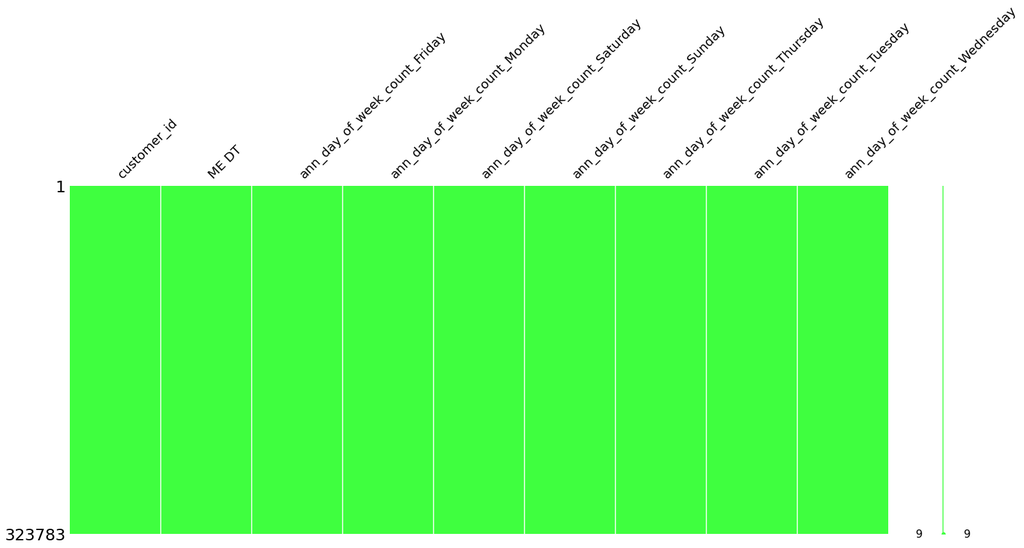

```python
mno.matrix(fnl_mth_day_counts,
    figsize=(25, 10),
    width_ratios=(20, 1),
    color=(0.25, 1.00, 0.25),
    fontsize=20,
    labels=None,
    label_rotation= 45,
    sparkline=True,
    freq=None,
    ax=None,)
```

```python
fnl_mth_day_counts.to_excel('mth_day_counts.xlsx')
```

## 1.7 Date-related features: days since last transaction

#### In this date-related features set, you want to capture the frequency of the transactions in terms of the days since the last transaction. This set of features applies only to the monthly features.

### 1. The starting point is again the txn table. Recall that most clients have a single purchase per month, but some clients have multiple purchases in a month. Since you want to calculate the ”days since last transaction”, you want to capture the last transaction in a month for every client.

#### Use the appropriate groupby to create the table last monthly purchase that captures the last ’txn date’ (aggfunc=max) for every client and month.

```python
txn1
```

|  | customer_id | tran_amount | txn_date | ME DT | YEAR | day_of_the_week | day_name |
| --- | --- | --- | --- | --- | --- | --- | --- |
| 0 | CS5295 | 35 | 2013-02-11 | 2013-02-28 | 2013 | 0 | Monday |
| 1 | CS4768 | 39 | 2015-03-15 | 2015-03-31 | 2015 | 6 | Sunday |
| 2 | CS2122 | 52 | 2013-02-26 | 2013-02-28 | 2013 | 1 | Tuesday |
| 3 | CS1217 | 99 | 2011-11-16 | 2011-11-30 | 2011 | 2 | Wednesday |
| 4 | CS1850 | 78 | 2013-11-20 | 2013-11-30 | 2013 | 2 | Wednesday |
| ... | ... | ... | ... | ... | ... | ... | ... |
| 124995 | CS8433 | 64 | 2011-06-26 | 2011-06-30 | 2011 | 6 | Sunday |
| 124996 | CS7232 | 38 | 2014-08-19 | 2014-08-31 | 2014 | 1 | Tuesday |
| 124997 | CS8731 | 42 | 2014-11-28 | 2014-11-30 | 2014 | 4 | Friday |
| 124998 | CS8133 | 13 | 2013-12-14 | 2013-12-31 | 2013 | 5 | Saturday |
| 124999 | CS7996 | 36 | 2014-12-13 | 2014-12-31 | 2014 | 5 | Saturday |

125000 rows × 7 columns

```python
agg_max = pd.NamedAgg(column = "txn_date", aggfunc = np.max)
last_monthly_purchase = txn1.groupby(['customer_id', 'ME DT']).agg(last_monthly_purchase = agg_max)
last_monthly_purchase
```

| customer_id | ME DT | last_monthly_purchase |
| --- | --- | --- |
| CS1112 | 2011-06-30 | 2011-06-15 |
|  | 2011-08-31 | 2011-08-19 |
|  | 2011-10-31 | 2011-10-02 |
|  | 2012-04-30 | 2012-04-08 |
|  | 2012-06-30 | 2012-06-24 |
| ... | ... | ... |
| CS9000 | 2014-01-31 | 2014-01-12 |
|  | 2014-05-31 | 2014-05-08 |
|  | 2014-07-31 | 2014-07-08 |
|  | 2014-08-31 | 2014-08-24 |
|  | 2015-02-28 | 2015-02-28 |

103234 rows × 1 columns

### 2. Join base table pd with last monthly purchase as you did in section 1.5. The snapshot below shows the output of the created object last monthly purchase base for client CS1112 who made her/his first purchase on June 2011, then no purchase on July and made a purchase again on August 2011. What values will you use to impute the NaT values here? NaT stands for ”Not a Timestamp”.

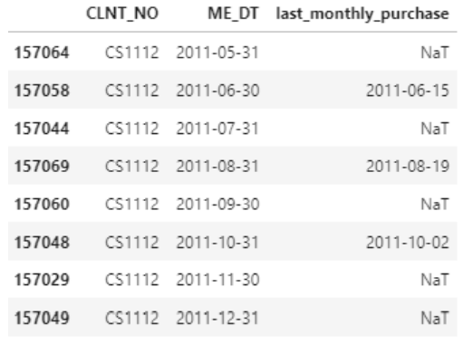

```python
last_monthly_purchase_base = base_table_pd.merge(right = last_monthly_purchase,
                                 how = 'left',
                                 on = ['customer_id', 'ME DT'])
last_monthly_purchase_base
```

|  | customer_id | ME DT | last_monthly_purchase |
| --- | --- | --- | --- |
| 0 | CS5295 | 2013-02-28 | 2013-02-11 |
| 1 | CS5295 | 2015-03-31 | NaT |
| 2 | CS5295 | 2011-11-30 | 2011-11-16 |
| 3 | CS5295 | 2013-11-30 | NaT |
| 4 | CS5295 | 2014-03-31 | NaT |
| ... | ... | ... | ... |
| 323778 | CS8077 | 2011-08-31 | 2011-08-28 |
| 323779 | CS8077 | 2012-09-30 | NaT |
| 323780 | CS8077 | 2014-09-30 | NaT |
| 323781 | CS8077 | 2014-02-28 | NaT |
| 323782 | CS8077 | 2012-06-30 | NaT |

323783 rows × 3 columns

```python
last_monthly_purchase_base = last_monthly_purchase_base.sort_values(by = ['customer_id', 'ME DT'], ascending = [True, True])
last_monthly_purchase_base
```

|  | customer_id | ME DT | last_monthly_purchase |
| --- | --- | --- | --- |
| 157064 | CS1112 | 2011-05-31 | NaT |
| 157058 | CS1112 | 2011-06-30 | 2011-06-15 |
| 157044 | CS1112 | 2011-07-31 | NaT |
| 157069 | CS1112 | 2011-08-31 | 2011-08-19 |
| 157060 | CS1112 | 2011-09-30 | NaT |
| ... | ... | ... | ... |
| 295140 | CS9000 | 2014-11-30 | NaT |
| 295126 | CS9000 | 2014-12-31 | NaT |
| 295119 | CS9000 | 2015-01-31 | NaT |
| 295136 | CS9000 | 2015-02-28 | 2015-02-28 |
| 295114 | CS9000 | 2015-03-31 | NaT |

323783 rows × 3 columns

### 3. To answer the imputation problem, we have to think what value should we use for say July 2011 for ’last monthly purchase’? The answer is that in July the value for the last monthly purchase is the previous line value: 2011-06-15. In other words, for every client we want to forward-fill the NaT values.

#### While pandas fillna() method has a method to forward-fill, here we want to use the apply and a lambda function with the forward-fill function ffill(), with the following expression: .apply(lambda x: x.ffill()) applied on object last monthly - purchase base grouped by CLNT NO. Below, I am showing a snapshot for lines [92:98] that confirm the transition between clients CS1113 and CS1114.

#### You can also recreate the forward-fill with the fillna() method, however there is a disadvantage and a reason the .apply() method is preferred here.

```python
last_monthly_purchase_base = last_monthly_purchase_base.groupby('customer_id').apply(lambda x: x.ffill())
last_monthly_purchase_base
```

|  | customer_id | ME DT | last_monthly_purchase |
| --- | --- | --- | --- |
| 157064 | CS1112 | 2011-05-31 | NaT |
| 157058 | CS1112 | 2011-06-30 | 2011-06-15 |
| 157044 | CS1112 | 2011-07-31 | 2011-06-15 |
| 157069 | CS1112 | 2011-08-31 | 2011-08-19 |
| 157060 | CS1112 | 2011-09-30 | 2011-08-19 |
| ... | ... | ... | ... |
| 295140 | CS9000 | 2014-11-30 | 2014-08-24 |
| 295126 | CS9000 | 2014-12-31 | 2014-08-24 |
| 295119 | CS9000 | 2015-01-31 | 2014-08-24 |
| 295136 | CS9000 | 2015-02-28 | 2015-02-28 |
| 295114 | CS9000 | 2015-03-31 | 2015-02-28 |

323783 rows × 3 columns

```python
last_monthly_purchase_base.iloc[92:97]
```

|  | customer_id | ME DT | last_monthly_purchase |
| --- | --- | --- | --- |
| 160011 | CS1113 | 2015-02-28 | 2015-02-09 |
| 159989 | CS1113 | 2015-03-31 | 2015-02-09 |
| 101134 | CS1114 | 2011-05-31 | NaT |
| 101128 | CS1114 | 2011-06-30 | NaT |
| 101114 | CS1114 | 2011-07-31 | 2011-07-14 |

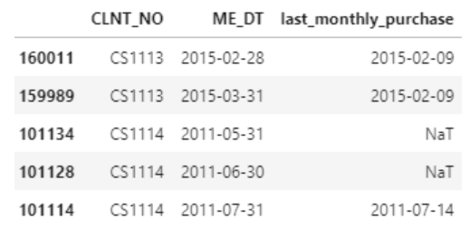

#### The forward-fill on the grouped by CLNT NO object is expected to leave NaT values for the first months of every client until they purchase something. The above snapshot confirms that for client CS1114.

### 4. Subtract the two date columns and convert the output to .dt.days to calculate the column ’days since last txn’ as shown in the following snapshot.

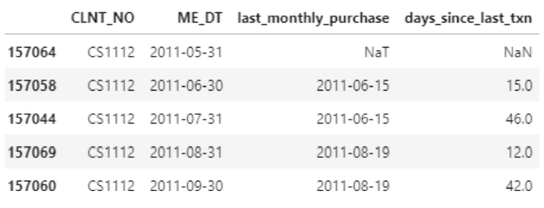

```python
last_monthly_purchase_base['days_since_last_txn'] = last_monthly_purchase_base['ME DT'] - last_monthly_purchase_base['last_monthly_purchase']
last_monthly_purchase_base['days_since_last_txn'] = last_monthly_purchase_base['days_since_last_txn'].dt.days
```

```python
last_monthly_purchase_base
```

|  | customer_id | ME DT | last_monthly_purchase | days_since_last_txn |
| --- | --- | --- | --- | --- |
| 157064 | CS1112 | 2011-05-31 | NaT | NaN |
| 157058 | CS1112 | 2011-06-30 | 2011-06-15 | 15.0 |
| 157044 | CS1112 | 2011-07-31 | 2011-06-15 | 46.0 |
| 157069 | CS1112 | 2011-08-31 | 2011-08-19 | 12.0 |
| 157060 | CS1112 | 2011-09-30 | 2011-08-19 | 42.0 |
| ... | ... | ... | ... | ... |
| 295140 | CS9000 | 2014-11-30 | 2014-08-24 | 98.0 |
| 295126 | CS9000 | 2014-12-31 | 2014-08-24 | 129.0 |
| 295119 | CS9000 | 2015-01-31 | 2014-08-24 | 160.0 |
| 295136 | CS9000 | 2015-02-28 | 2015-02-28 | 0.0 |
| 295114 | CS9000 | 2015-03-31 | 2015-02-28 | 31.0 |

323783 rows × 4 columns

### 5. Plot a histogram of the ’days since last txn’. Based on the values you observe in the histogram, impute the remaining NaN values (i.e. for the initial months before a client makes a purchase). Save the columns [’CLNT NO’, ’ME DT’, ’days since last txn’] as days since last txn.xlsx.

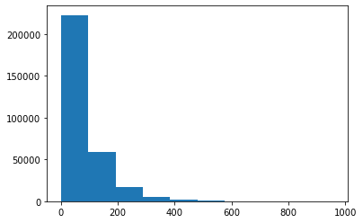

```python
plt.hist(last_monthly_purchase_base['days_since_last_txn'])
```

```python
last_monthly_purchase_base = last_monthly_purchase_base.fillna(-1)
```

```python
temp2 = last_monthly_purchase_base.drop('last_monthly_purchase', axis = 1)
temp2
```

|  | customer_id | ME DT | days_since_last_txn |
| --- | --- | --- | --- |
| 157064 | CS1112 | 2011-05-31 | -1.0 |
| 157058 | CS1112 | 2011-06-30 | 15.0 |
| 157044 | CS1112 | 2011-07-31 | 46.0 |
| 157069 | CS1112 | 2011-08-31 | 12.0 |
| 157060 | CS1112 | 2011-09-30 | 42.0 |
| ... | ... | ... | ... |
| 295140 | CS9000 | 2014-11-30 | 98.0 |
| 295126 | CS9000 | 2014-12-31 | 129.0 |
| 295119 | CS9000 | 2015-01-31 | 160.0 |
| 295136 | CS9000 | 2015-02-28 | 0.0 |
| 295114 | CS9000 | 2015-03-31 | 31.0 |

323783 rows × 3 columns

```python
temp2.to_excel('days_since_last_txn.xlsx')
```